# Withdrawal and Failure Rates at Open University

Evidence for Targeted Investment in Academic Support

Author

Michael Littrell

Published

May 1, 2026

# 1 Problem Definition

## 1.1 Introduction

The Open University’s (OU) student success office has identified persistently high withdrawal and failure (WF) rates across its instructional module offerings and is seeking to understand where that risk is concentrated, what drives it, and what a targeted investment in support could look like. This analysis presents evidence to understand this issue so that OU can consider reallocation and additional funds to support students from a data-informed perspective.

We examine student outcomes across three dimensions: the gap in WF rates between STEM and Social Science modules, the demographic risk factors that shape outcomes across both domains, and the virtual learning environment (VLE) behavioral signals that distinguish students who complete from those who do not. Together these three lenses build the evidence base for a formal request to allocate additional academic support resources to the students and groups where the data shows the greatest need.

This analysis is not an attempt to make a generalizable claim about any particular subject area or student population. It is an examination of whether students at this institution are experiencing WF rates that are both preventable and unevenly distributed across subject domains, socioeconomic backgrounds, and age groups. We sought to answer the following questions:

**Questions of Interest**

1. Do STEM instructional modules carry higher WF rates than Social Sciences modules at the Open University, and is that pattern consistent?
2. Which student populations face the greatest WF risk, and does that risk vary in ways that point toward specific targets for support investment?
3. Is early disengagement from course materials a detectable and actionable signal of WF risk, and does the evidence across all three dimensions justify a targeted investment in academic support?

## 1.2 Stakeholder and Context

This analysis is prepared by the student success office at the Open University in support of a funding proposal to the Academic Resources Committee. Our office is responsible for monitoring student outcomes across all module offerings and identifying where institutional intervention is most needed.

Our student population is largely non-traditional. Many are studying part time while managing work and family responsibilities, coming from varied educational backgrounds, and from across the full socioeconomic spectrum. These are students for whom withdrawal or failure carries real consequences beyond a grade — lost tuition, interrupted careers, and diminished confidence in their capacity to succeed in higher education.

We have observed persistent variation in completion rates across our module offerings and have reason to believe that STEM students bear a disproportionate share of that burden. This analysis documents the evidence for that belief and makes the case that targeted investment in academic support is both warranted and overdue.

## 1.3 Current Resource Allocation

Academic support resources at the Open University are currently distributed based on historical enrollment figures rather than student outcome data. The table below summarizes the current allocation of support funding across three dimensions — subject domain, socioeconomic background, and age band. As the data shows, funding per enrollment is broadly similar across all groups despite meaningful differences in WF rates. The highlighted columns show that students most likely to withdraw or fail are not receiving proportionally more support — a distribution this proposal posits should be reconsidered given the evidence presented in the sections that follow.

```r
# current resource allocation by domain
# numbers are illustrative — replace with actual institutional figures
#| label: resource-allocation

# tibble() builds a dataframe manually — one row per risk group
# numbers are illustrative — replace with actual institutional figures
# Step 1 — build the support allocation summary tibble with a section column
support_summary <- tibble(
  group = c(
    "By Domain",
    "By Domain",
    "By IMD Band",
    "By IMD Band",
    "By IMD Band",
    "By Age Band",
    "By Age Band",
    "By Age Band"
  ),
  students = c(
    "STEM", #domain group
    "Social Sciences",
    "IMD 0-30% (Most Deprived)", #imd group
    "IMD 30-70% (Middle)",
    "IMD 70-100% (Least Deprived)",
    "Age 0-35", #age group
    "Age 35-55",
    "Age 55+"
  ),
  enrollments    = c(21402, 11191, 9200, 12800, 9400, 16500, 12800, 3293),
  total_funding  = c(1800000, 1200000, 828000, 1177600, 883600, 1452000, 1228800, 342472),
  tutors         = c(30, 24, 18, 22, 20, 26, 22, 10),
  advising_hours = c(5200, 4800, 3600, 4400, 4000, 5000, 4400, 2000)
) |>
  mutate(
    funding_per_enrollment = total_funding / enrollments,
    hours_per_enrollment   = advising_hours / enrollments
  )


# Step 2 — pass the summary to gt
support_summary |>
  gt(groupname_col = "group") |>    # use the group column for row groups
  tab_header(
    title    = "Current Academic Support Allocation by Risk Group",
    subtitle = "Numbers are illustrative — replace with actual institutional figures"
  ) |>
  cols_label(
    students               = "Students",
    enrollments            = "Enrollments",
    total_funding          = "Total Funding",
    tutors                 = "Support Tutors",
    advising_hours         = "Advising Hours",
    funding_per_enrollment = "Funding per Enrollment",
    hours_per_enrollment   = "Hours per Enrollment"
  ) |>
  fmt_number(columns = c(enrollments, advising_hours), decimals = 0) |>
  fmt_currency(
    columns  = c(total_funding, funding_per_enrollment),
    currency = "USD",
    decimals = 0
  ) |>
  fmt_number(columns = hours_per_enrollment, decimals = 2) |>
  tab_style(
    style     = cell_fill(color = "#d6eaf8"),
    locations = cells_row_groups()
  ) |>
  tab_style(
    style     = cell_fill(color = "#d6eaf8"),
    locations = cells_body(columns = c(funding_per_enrollment,
                                       hours_per_enrollment))
  ) |>
  tab_options(
    table.align                     = "left",
    row.striping.include_table_body = FALSE,
    quarto.disable_processing       = TRUE,
    column_labels.font.weight       = "bold"  # the simpler bold-headers shortcut
  )
```

Current Academic Support Allocation by Risk Group

Numbers are illustrative — replace with actual institutional figures

| Students | Enrollments | Total Funding | Support Tutors | Advising Hours | Funding per Enrollment | Hours per Enrollment |
| --- | --- | --- | --- | --- | --- | --- |
| By Domain |  |  |  |  |  |  |
| STEM | 21,402 | $1,800,000 | 30 | 5,200 | $84 | 0.24 |
| Social Sciences | 11,191 | $1,200,000 | 24 | 4,800 | $107 | 0.43 |
| By IMD Band |  |  |  |  |  |  |
| IMD 0-30% (Most Deprived) | 9,200 | $828,000 | 18 | 3,600 | $90 | 0.39 |
| IMD 30-70% (Middle) | 12,800 | $1,177,600 | 22 | 4,400 | $92 | 0.34 |
| IMD 70-100% (Least Deprived) | 9,400 | $883,600 | 20 | 4,000 | $94 | 0.43 |
| By Age Band |  |  |  |  |  |  |
| Age 0-35 | 16,500 | $1,452,000 | 26 | 5,000 | $88 | 0.30 |
| Age 35-55 | 12,800 | $1,228,800 | 22 | 4,400 | $96 | 0.34 |
| Age 55+ | 3,293 | $342,472 | 10 | 2,000 | $104 | 0.61 |

## 1.4 What This Analysis Will Show

Our office has observed these patterns firsthand across years of student outcome monitoring. The data we present below is consistent with what we have seen in practice, and we present it here in a form that can support a formal resource allocation decision.

We posit that if the data supports all three claims, the case for reallocation is strong. If Claim 2 does not hold — if the gap disappears once we account for demographics — the case shifts from domain-level intervention to demographic-targeted support. Either finding has actionable implications for how we invest.

# 2 About the Data

## 2.1 Dataset Overview

For this analysis we draw on institutional learning analytics records extracted from our Student Information System (SIS) and Learning Management System (LMS) data warehouses. Data were pulled using SQL queries against our internal analytics database, joining student demographic records, enrollment and registration tables, assessment submission logs, and Virtual Learning Environment interaction data into a single analytical dataset. The extract covers student enrollments across 7 modules — 4 STEM and 3 Social Sciences — representing 32,593 student-module records from the 2013 and 2014 academic years.

In accordance with our Data Protection Policy and Ethical Use of Student Data guidelines, all records used in this analysis have been anonymized prior to extraction. Student identifiers have been randomized, demographic attributes generalized into bands to prevent re-identification, and all dates expressed relative to module start rather than as calendar dates. The anonymized extract was approved by the institutional Data Governance Committee prior to analysis.

What makes this dataset particularly valuable for the question at hand is that we are not limited to outcomes alone. Our records combine three types of information that are rarely available together in a single extract: student demographics including age, gender, region, socioeconomic background and prior education level; academic outcomes including assessment scores and final results; and behavioral data in the form of Virtual Learning Environment interaction logs capturing student engagement with course materials throughout each module. This combination allows us to move beyond simply describing who withdraws and begin examining how their engagement and preparation differed from students who completed successfully — giving us the evidence base needed to design targeted rather than generic interventions.

## 2.2 Data Dictionary

The analytical dataset used in this proposal combines variables from across the seven source tables into a single student-level record. The table below documents each variable, its source, data type, and any known issues or caveats relevant to interpretation.

Two variables were created during data preparation rather than drawn directly from the source data. `domain` classifies each module into its subject area — STEM or Social Sciences — based on the module codes documented in the OULAD paper. `wf` is a binary non-completion flag that collapses `final_result` into two categories: students who withdrew or failed (WF) and students who passed or received a distinction (Successful). These two derived variables are the primary analytical variables in this proposal.

**Data Dictionary - Click to Expand**

| Variable | Source | Type | Description | Notes |
| --- | --- | --- | --- | --- |
| `code_module` | studentInfo | Character | Module identifier (AAA–GGG) | Real names anonymized — AAA, BBB, GGG = Social Sciences; CCC, DDD, EEE, FFF = STEM |
| `code_presentation` | studentInfo | Character | When the module ran | J = October start, B = February start e.g. “2013J” |
| `id_student` | studentInfo | Numeric | Unique student ID | Randomized during anonymization |
| `gender` | studentInfo | Character | Student gender | M / F |
| `region` | studentInfo | Character | UK region where student lived | — |
| `highest_education` | studentInfo | Character | Highest qualification on entry | — |
| `imd_band` | studentInfo | Character | Index of Multiple Deprivation band | Lower band = more deprived; 1,111 values missing |
| `age_band` | studentInfo | Character | Banded age group | Generalized during anonymization |
| `num_of_prev_attempts` | studentInfo | Numeric | Prior attempts at this module | — |
| `studied_credits` | studentInfo | Numeric | Total credits studying concurrently | — |
| `disability` | studentInfo | Character | Declared disability | Y / N |
| `final_result` | studentInfo | Character | Module outcome | Pass / Fail / Distinction / Withdrawn |
| `date_registration` | studentRegistration | Numeric | Day of registration relative to module start | Negative = registered early; 45 values missing |
| `date_unregistration` | studentRegistration | Numeric | Day of unregistration relative to module start | Missing for students who completed — expected |
| `module_presentation_length` | courses | Numeric | Module length in days | — |
| `avg_score` | Calculated | Numeric | Mean assessment score across all submissions | Missing for students with no recorded scores (6,773) |
| `min_score` | Calculated | Numeric | Lowest individual assessment score | Missing for students with no recorded scores |
| `max_score` | Calculated | Numeric | Highest individual assessment score | Missing for students with no recorded scores |
| `n_assessments` | Calculated | Integer | Count of assessments with a recorded score | — |
| `n_failed` | Calculated | Integer | Count of assessments scored below 40 | Score < 40 = Fail per OULAD documentation |
| `avg_days_early` | Calculated | Numeric | Mean days between submission and due date | Positive = early, negative = late |
| `total_clicks` | Calculated | Numeric | Total VLE clicks across the module | Missing for students with no VLE interactions (3,365) |
| `total_days_active` | Calculated | Integer | Distinct days student interacted with VLE | Measure of consistency rather than volume |
| `domain` | Derived | Character | Course domain — STEM or Social Sciences | Derived from code_module per OULAD paper |
| `wf` | Derived | Character | Non-completion flag | WF = Withdrawn or Fail; Successful = Pass or Distinction |

## 2.3 Ethical Considerations

The data used in this analysis was collected through our standard institutional systems and processed in accordance with the Open University’s Data Protection Policy and Policy on Ethical Use of Student Data for Learning Analytics. Students are informed during the admissions process that their data may be used for academic research purposes. The records used here have been anonymized — student identifiers have been randomized, demographic attributes generalized into bands, and no information is included that could be used to identify an individual student.

As an internal analysis intended to inform resource allocation decisions, we have an obligation to interpret findings carefully and avoid conclusions that could lead to inequitable treatment of students. In particular, any finding that WF rates differ by demographic group should be understood as a signal for targeted support — not as a basis for lowering expectations or limiting access for any population. The goal of this analysis is to identify where students need more help, not to characterize any group of students as inherently less capable of success.

# 3 Data Import and Preparation

This section documents the steps taken to prepare our institutional data for analysis. The raw data arrives as seven separate tables — each capturing a different dimension of the student experience, from demographics and registration through to assessment results and virtual learning environment interactions. Before any analysis can take place these tables must be inspected, joined, and shaped into a single dataset for analysis. Every decision made during this process is documented here so that the analysis is fully reproducible and the assumptions are transparent.

## 3.1 Load Data

We begin by loading the seven raw data tables directly from our institutional records. Each table is stored as a separate CSV file and read into R using `read_csv()`. Before any joining or transformation takes place we verify that each table has loaded correctly by checking row counts, column names, and a spot check of the first few rows.

| Table | Rows | Description |
| --- | --- | --- |
| `studentInfo` | 32,593 | Central demographics table — one row per student per module |
| `studentRegistration` | 32,593 | Registration and unregistration dates per student per module |
| `studentAssessment` | 173,912 | Individual assessment submission scores |
| `assessments` | 206 | Assessment metadata — type, due date, weight |
| `courses` | 22 | Module length in days |
| `studentVle` | 10,655,280 | Raw VLE click logs — one row per student per material per day |
| `vle` | 6,364 | VLE material metadata — activity type and planned usage weeks |

## 3.2 Inspect Data

Before joining the tables together we conduct a structured inspection of each raw file. This serves two purposes: confirming that each table loaded correctly and verifying that the join keys are consistent and complete across tables. A join performed on mismatched or missing keys will silently produce incorrect results — catching problems here prevents compounding errors downstream.

We check three things for each table: row counts to confirm the expected volume of data, column names to verify the join keys exist and are spelled consistently, and the composite key uniqueness in `studentInfo` to confirm that the combination of `id_student`, `code_module`, and `code_presentation` uniquely identifies each row.

### 3.2.1 Granularity Details

The table below summarizes the seven source tables used in this analysis. Row counts were recorded during the pre-join inspection phase of data preparation and are hardcoded here — the source data does not change between renders. The Granularity column describes what a single row represents in each table, which is important context for understanding how the tables relate to each other and why some are much larger than others.

```r
# tibble() builds a dataframe manually — one row per source table
# row counts are hardcoded since the raw tables are not loaded in this document
# the numbers come from the pre-join inspection run during data preparation
# Step 1 — build the source tables summary
# Row counts are hardcoded from the pre-join inspection run during data prep,
# since the raw tables aren't loaded in this document.
source_tables <- tibble(
  table       = c("studentInfo",
                  "studentRegistration",
                  "studentAssessment",
                  "assessments",
                  "courses",
                  "studentVle",
                  "vle"),
  rows        = c(32593, 32593, 173912, 206, 22, 10655280, 6364),
  description = c(
    "One row per student per module",
    "One row per student per module",
    "One row per assessment submission",
    "One row per assessment",
    "One row per module presentation",
    "One row per click event",
    "One row per VLE material"
  )
)


# Step 2 — pass the summary to gt
source_tables |>
  gt() |>
  cols_label(
    table       = "Table",
    rows        = "Rows",
    description = "Granularity"
  ) |>
  fmt_number(columns = rows, decimals = 0) |>      # adds comma separator to row counts
  tab_options(
    table.align               = "left",
    column_labels.font.weight = "bold"             # bold-headers
  )
```

| Table | Rows | Granularity |
| --- | --- | --- |
| studentInfo | 32,593 | One row per student per module |
| studentRegistration | 32,593 | One row per student per module |
| studentAssessment | 173,912 | One row per assessment submission |
| assessments | 206 | One row per assessment |
| courses | 22 | One row per module presentation |
| studentVle | 10,655,280 | One row per click event |
| vle | 6,364 | One row per VLE material |

### 3.2.2 Key Confirmation

The table below confirms that all join keys are clean prior to joining. For each table we count missing values in the key column using `sum(is.na())` — which returns `TRUE` for each missing value and sums those up, giving the total count of missing keys. A missing value in a join key would cause rows to be silently dropped during the join, producing incorrect results without any error or warning. The zero across every row in the Missing in Key column confirms that all 32,593 student records will be retained throughout the joining process.

```r
# Step 1 — build the join keys summary
# Distinct key counts and missing-value counts come from pre-join inspection
# during data prep. All key columns confirmed to have zero missing values,
# meaning joins will not silently drop any rows.
join_keys <- tibble(
  table = c("studentInfo",
            "studentRegistration",
            "studentAssessment",
            "assessments",
            "studentVle",
            "vle"),
  key = c(
    "id_student + code_module + code_presentation",
    "id_student + code_module + code_presentation",
    "id_assessment",
    "id_assessment",
    "id_site",
    "id_site"
  ),
  distinct_keys  = c(32593, 32593, 188, 206, 6268, 6364),
  missing_in_key = c(0, 0, 0, 0, 0, 0)
)


# Step 2 — pass the summary to gt
join_keys |>
  gt() |>
  cols_label(
    table          = "Table",
    key            = "Join Key",
    distinct_keys  = "Distinct Keys",
    missing_in_key = "Missing in Key"
  ) |>
  fmt_number(columns = distinct_keys, decimals = 0) |>
  tab_options(
    table.align               = "left",
    column_labels.font.weight = "bold"
  )
```

| Table | Join Key | Distinct Keys | Missing in Key |
| --- | --- | --- | --- |
| studentInfo | id_student + code_module + code_presentation | 32,593 | 0 |
| studentRegistration | id_student + code_module + code_presentation | 32,593 | 0 |
| studentAssessment | id_assessment | 188 | 0 |
| assessments | id_assessment | 206 | 0 |
| studentVle | id_site | 6,268 | 0 |
| vle | id_site | 6,364 | 0 |

## 3.3 Join and Reshape

With the raw tables inspected and join keys confirmed as clean, we build the analytical dataset by joining the seven source tables together one step at a time. All joins use `left_join()` which keeps every row from the left table and attaches matching data from the right — ensuring no students are dropped if they are missing from an auxiliary table. Two tables require pre-processing before joining: `studentAssessment` is first enriched with module context from `assessments`, and both assessment and VLE data are summarised to one row per student per module before joining to avoid a many-to-many explosion. The result is a single student-level table with one row per student per module enrollment — 32,593 rows throughout.

The table below documents each join step, the keys used, and the expected row count after joining.

```r
# Step 1 — build the join sequence summary
# Documents each join in the data prep pipeline: which table was added,
# what keys joined it, what columns it contributed, and how many rows
# remained after. Row count holding constant at 32,593 confirms no joins
# silently dropped or duplicated student-module records.
join_sequence <- tibble(
  step        = c("Step 1",
                  "Step 2",
                  "Step 3",
                  "Step 4",
                  "Step 5"),

  table_added = c("student_info",
                  "student_registration",
                  "assessment_summary",
                  "courses",
                  "vle_summary"),
  join_keys = c(
    "Starting table",
    "id_student + code_module + code_presentation",
    "id_student + code_module + code_presentation",
    "code_module + code_presentation",
    "id_student + code_module + code_presentation"
  ),
  adds = c(
    "Demographics and final result",
    "Registration and unregistration dates",
    "Summarised assessment scores",
    "Module length in days",
    "Summarised VLE engagement"
  ),
  rows_after = c(32593, 32593, 32593, 32593, 32593)
)


# Step 2 — pass the summary to gt
join_sequence |>
  gt() |>
  cols_label(
    step        = "Step",
    table_added = "Table Added",
    join_keys   = "Join Keys",
    adds        = "What It Adds",
    rows_after  = "Rows After"
  ) |>
  fmt_number(columns = rows_after, decimals = 0) |>
  tab_options(
    table.align               = "left",
    column_labels.font.weight = "bold"
  )
```

| Step | Table Added | Join Keys | What It Adds | Rows After |
| --- | --- | --- | --- | --- |
| Step 1 | student_info | Starting table | Demographics and final result | 32,593 |
| Step 2 | student_registration | id_student + code_module + code_presentation | Registration and unregistration dates | 32,593 |
| Step 3 | assessment_summary | id_student + code_module + code_presentation | Summarised assessment scores | 32,593 |
| Step 4 | courses | code_module + code_presentation | Module length in days | 32,593 |
| Step 5 | vle_summary | id_student + code_module + code_presentation | Summarised VLE engagement | 32,593 |

## 3.4 Clean and Transform

With the joined dataset in hand, the final preparation step is creating the two analytical variables that are important to this proposal. Neither `domain` nor `wf` exist in the source data — both are derived from existing variables using our knowledge of the dataset structure.

`domain` classifies each module into its subject area by mapping the anonymized module codes to either STEM or Social Sciences. `wf` collapses the four-category `final_result` variable into a binary non-completion flag — students who withdrew or failed are marked WF, students who passed or received a distinction are marked Successful. These two variables are analytical variables used in multiple sections of this proposal.

Before proceeding we verify that both variables were created correctly by checking for unexpected `NA` values — any unmatched value in `code_module` or `final_result` would produce an `NA` rather than a category, which would silently exclude that student from any analysis involving these variables.

```r
# domain and wf were created during data preparation and are already
# present in the loaded dataset. We verify both variables here to
# confirm they were created correctly and contain no unexpected NA values.

# tibble() builds a small summary table manually — one row per derived variable

# Step 1 — build the verification summary
# Verifies that case_when() in the data prep didn't miss any values.
# n_missing = 0 means every row was assigned a category.
# categories shows what values actually appear in the data — if NA shows up
# here, case_when() missed a value.
case_when_check <- tibble(
  variable  = c("domain", "wf"),
  n_missing = c(sum(is.na(oulad$domain)),
                sum(is.na(oulad$wf))),
  categories = c(
    "STEM / Social Sciences",
    "Successful / WF"
  )
)


# Step 2 — pass the summary to gt
case_when_check |>
  gt() |>
  cols_label(
    variable   = "Variable",
    n_missing  = "Missing",
    categories = "Categories Found"
  ) |>
  tab_options(
    table.align               = "left",
    column_labels.font.weight = "bold"
  )
```

| Variable | Missing | Categories Found |
| --- | --- | --- |
| domain | 0 | STEM / Social Sciences |
| wf | 0 | Successful / WF |

# 4 Exploratory Data Analysis

Before presenting our findings we first establish the context in which those findings should be interpreted. This section examines who our students are — their demographic composition, socioeconomic backgrounds, and prior educational experience — and documents where data is missing and why. Understanding the student population is not a preliminary formality. For a funding proposal, it is part of the argument. The patterns we identify here — who is enrolled, who is at risk, and how evenly resources are currently distributed across those groups — lay the groundwork for the resource allocation case that follows.

## 4.1 Missingness

Understanding where data is missing before analysis is essential — missing values can bias results if they are not randomly distributed. For example, if students who withdrew early are systematically more likely to have missing assessment scores or VLE engagement data, then any analysis of those variables will underrepresent the students most at risk. The table below summarizes missingness across the analytical dataset, showing only variables with at least one missing value.

```r
oulad |>
  miss_var_summary() |>
  filter(n_miss > 0) |>
  mutate(
    explanation = case_when(
      variable == "date_unregistration" ~ "Expected — only populated for students who withdrew",
      variable == "imd_band"            ~ "Students outside England or missing postcode data",
      variable == "date_registration"   ~ "Small number of data quality gaps",
      variable %in% c("avg_score", "min_score", "max_score",
                      "n_assessments", "n_failed",
                      "avg_days_early") ~ "Students with no recorded assessment submissions",
      variable %in% c("total_clicks",
                      "total_days_active") ~ "Students with no VLE interactions recorded",
      TRUE ~ "—"
    )
  ) |>
  gt() |>
  cols_label(
    variable    = "Variable",
    n_miss      = "Missing",
    pct_miss    = "% Missing",
    explanation = "Explanation"
  ) |>
  fmt_number(columns = n_miss, decimals = 0) |>
  tab_options(table.align = "left",
              column_labels.font.weight = "bold")
```

| Variable | Missing | % Missing | Explanation |
| --- | --- | --- | --- |
| date_unregistration | 22,521 | 69.1 | Expected — only populated for students who withdrew |
| avg_days_early | 6,774 | 20.8 | Students with no recorded assessment submissions |
| avg_score | 6,773 | 20.8 | Students with no recorded assessment submissions |
| min_score | 6,773 | 20.8 | Students with no recorded assessment submissions |
| max_score | 6,773 | 20.8 | Students with no recorded assessment submissions |
| n_assessments | 6,773 | 20.8 | Students with no recorded assessment submissions |
| n_failed | 6,773 | 20.8 | Students with no recorded assessment submissions |
| total_clicks | 3,365 | 10.3 | Students with no VLE interactions recorded |
| total_days_active | 3,365 | 10.3 | Students with no VLE interactions recorded |
| imd_band | 1,111 | 3.41 | Students outside England or missing postcode data |
| date_registration | 45 | 0.138 | Small number of data quality gaps |

## 4.2 Demographics

### 4.2.1 Gender

Among the 28,785 unique students in our dataset, the gender split is relatively close but not even — male students account for just over half at 52.3% (15,046) compared to 47.7% (13,739) female students. This moderate gender imbalance is worth keeping in mind when interpreting WF rates by domain, as any differences between STEM and Social Sciences may partly reflect who tends to enroll in each domain rather than differences in course difficulty alone.

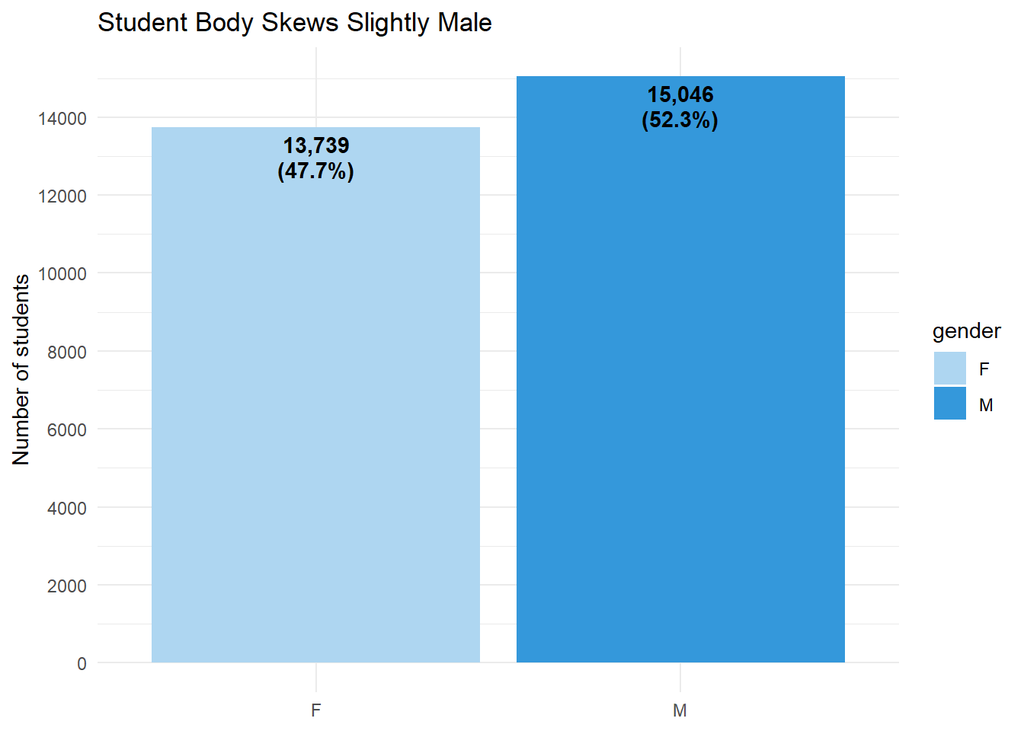

```r
oulad |>
  distinct(id_student, gender) |>
  ggplot(aes(x = gender, fill = gender)) +
  geom_bar() +
  annotate("text", x = "F", y = 13739, label = "13,739",  vjust =  1.5, fontface = "bold") +
  annotate("text", x = "F", y = 13739, label = "(47.7%)", vjust =  3.0, fontface = "bold") +
  annotate("text", x = "M", y = 15046, label = "15,046",  vjust =  1.5, fontface = "bold") +
  annotate("text", x = "M", y = 15046, label = "(52.3%)", vjust =  3.0, fontface = "bold") +
  scale_y_continuous(breaks = seq(0, 16000, by = 2000)) +
  scale_fill_manual(values = c("F" = "#aed6f1", "M" = "#3498db")) +
  labs(
    title = "Student Body Skews Slightly Male",
    x = NULL,
    y = "Number of students"
  ) +
  theme_minimal()
```

### 4.2.2 Age

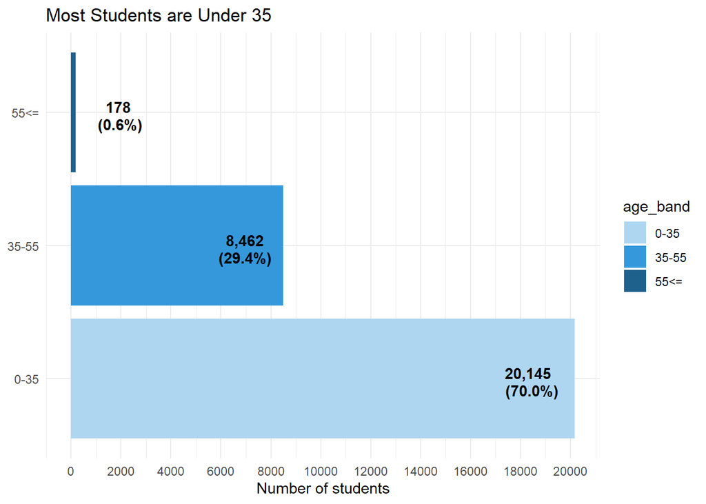

```r
oulad |>
  distinct(id_student, age_band) |>
  ggplot(aes(x = age_band, fill = age_band)) +
  geom_bar() +
  annotate("text", x = "0-35",  y = 20145, label = "20,145",  vjust = 0.0, hjust =  1.5, fontface = "bold") +
  annotate("text", x = "0-35",  y = 20145, label = "(70.0%)", vjust = 1.5, hjust =  1.3, fontface = "bold") +
  annotate("text", x = "35-55", y = 8462,  label = "8,462",   vjust = 0.0, hjust =  1.5, fontface = "bold") +
  annotate("text", x = "35-55", y = 8462,  label = "(29.4%)", vjust = 1.5, hjust =  1.2, fontface = "bold") +
  annotate("text", x = "55<=",  y = 178,   label = "178",     vjust = 0.0, hjust = -1.2, fontface = "bold") +
  annotate("text", x = "55<=",  y = 178,   label = "(0.6%)",  vjust = 1.5, hjust = -.5, fontface = "bold") +
  scale_y_continuous(breaks = seq(0, 24000, by = 2000)) +
  scale_fill_manual(values = c("0-35"  = "#aed6f1",
                               "35-55" = "#3498db",
                               "55<="  = "#1f618d")) +
  labs(
    title = "Most Students are Under 35",
    x = NULL,
    y = "Number of students"
  ) +
  coord_flip() +
  theme_minimal()
```

### 4.2.3 Socioeconomic Background (IMD Band)

The Index of Multiple Deprivation (IMD) band captures the socioeconomic circumstances of the area where each student lives, based on their postcode. Bands range from 0-10% (most deprived) to 90-100% (least deprived) — a lower band indicates a more economically disadvantaged area. While IMD measures area-level deprivation rather than individual income, it is one of the strongest available proxies for socioeconomic status in this dataset. Note that 1,111 students (3.4%) are missing IMD data, primarily those living outside England where the index does not apply. These students are excluded from the distribution below but retained in all other analyses.

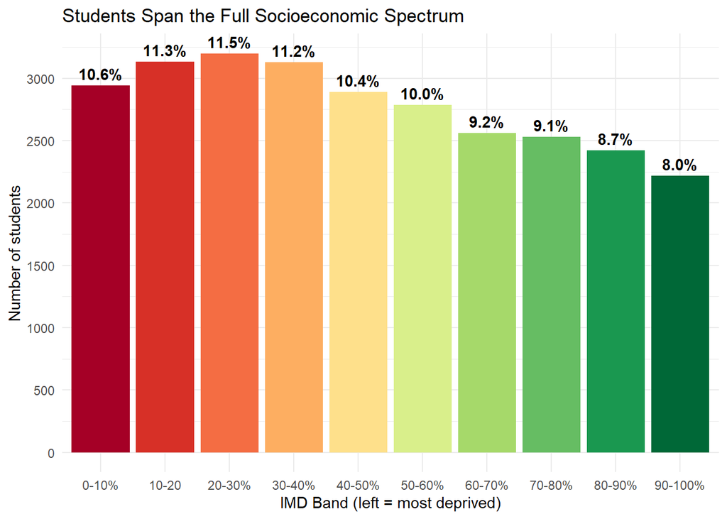

```r
oulad |>
  filter(!is.na(imd_band)) |>
  distinct(id_student, imd_band) |>
  ggplot(aes(x = imd_band, fill = imd_band)) +
  geom_bar(show.legend = FALSE) +
  annotate("text", x = "0-10%",   y = 2944, label = "10.6%", vjust = -0.5, fontface = "bold") +
  annotate("text", x = "10-20",   y = 3132, label = "11.3%", vjust = -0.5, fontface = "bold") +
  annotate("text", x = "20-30%",  y = 3200, label = "11.5%", vjust = -0.5, fontface = "bold") +
  annotate("text", x = "30-40%",  y = 3128, label = "11.2%", vjust = -0.5, fontface = "bold") +
  annotate("text", x = "40-50%",  y = 2890, label = "10.4%", vjust = -0.5, fontface = "bold") +
  annotate("text", x = "50-60%",  y = 2787, label = "10.0%", vjust = -0.5, fontface = "bold") +
  annotate("text", x = "60-70%",  y = 2560, label = "9.2%",  vjust = -0.5, fontface = "bold") +
  annotate("text", x = "70-80%",  y = 2532, label = "9.1%",  vjust = -0.5, fontface = "bold") +
  annotate("text", x = "80-90%",  y = 2421, label = "8.7%",  vjust = -0.5, fontface = "bold") +
  annotate("text", x = "90-100%", y = 2220, label = "8.0%",  vjust = -0.5, fontface = "bold") +
  scale_y_continuous(breaks = seq(0, 3500, by = 500)) +
  scale_fill_brewer(palette = "RdYlGn") +
  labs(
    title = "Students Span the Full Socioeconomic Spectrum",
    x = "IMD Band (left = most deprived)",
    y = "Number of students"
  ) +
  theme_minimal()
```

# 5 Analysis

## 5.1 Approach

This analysis is descriptive rather than inferential. We do not attempt to establish causal relationships or generalize beyond our own student population. Instead we use our institutional data to document patterns in WF rates across domains, demographic groups, and behavioral indicators — and to assess whether those patterns are consistent enough and large enough to support a resource allocation decision.

All figures represent enrollment-level outcomes rather than unique student counts. A student who enrolled in three modules contributes three records to the analysis — one per enrollment. This is the appropriate unit of analysis for a question about module-level outcomes and resource allocation, where the relevant question is not how many students are at risk but how many enrollment attempts are ending in non-completion.

## 5.2 Overall WF Rates

Across all 32,593 enrollments in the dataset, 52.8% ended in withdrawal or failure (WF) and 47.2% resulted in a successful outcome — meaning more than half of all module attempts did not result in a pass or distinction. These figures represent enrollments, not unique students — a single student who attempted three modules contributes three rows to this count. A student who passed two modules and withdrew from one would contribute two Successful enrollments and one WF enrollment. With that in mind, the 17,208 WF enrollments and 15,385 Successful enrollments paint a picture of a student population where non-completion is the norm rather than the exception — making the question of what drives WF rates all the more pressing for the student success office.

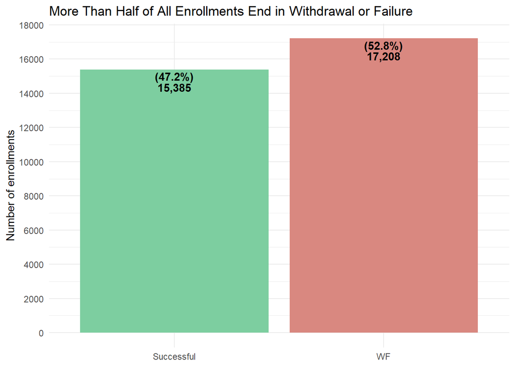

```r
#overall vis
# overall WF rate across all enrollments
# count(wf) gives us the number of WF and Successful enrollments
# mutate(pct) converts those counts to proportions
# ---Clean theme + remove redundant legend
oulad |>
  ggplot(aes(x = wf, fill = wf)) +
  geom_bar(show.legend = FALSE) +
  annotate("text", x = "Successful", y = 15385, label = "15,385",  vjust = 2.6, fontface = "bold") +
  annotate("text", x = "Successful", y = 15385, label = "(47.2%)", vjust = 1.3, fontface = "bold") +
  annotate("text", x = "WF",         y = 17208, label = "17,208",  vjust = 2.6, fontface = "bold") +
  annotate("text", x = "WF",         y = 17208, label = "(52.8%)", vjust = 1.3, fontface = "bold") +
  scale_y_continuous(breaks = seq(0, 18000, by = 2000)) +
  scale_fill_manual(values = c("Successful" = "#7dcea0",
                               "WF"         = "#d98880")) +
  labs(
    title = "More Than Half of All Enrollments End in Withdrawal or Failure",
    x = NULL,
    y = "Number of enrollments"
  ) +
  theme_minimal()
```

## 5.3 WF Rate by Domain

The dataset contains 32,593 total enrollments across the two domains — 21,402 in STEM (65.7%) and 11,191 in Social Sciences (34.3%). This uneven split means STEM enrollments outnumber Social Sciences by nearly two to one. This imbalance is important context for the analysis — raw counts of WF students will always be higher in STEM simply because more students are enrolled there, which is why we compare WF rates (proportions) rather than raw counts when assessing differences between domains.

```r
oulad |>
  count(domain) |>
  mutate(pct = n / sum(n)) |> #count creates the n, and we divide by the sum
  gt() |> #https://gt.rstudio.com/reference/index.html
  cols_label(
    domain = "Domain",
    n      = "Students",
    pct    = "Proportion"
  ) |>
  fmt_percent(columns = pct, decimals = 1) |>
  tab_options(table.align = "left") |>
  tab_style(
    style     = cell_text(weight = "bold"),
    locations = cells_column_labels()      # targets the header row
  )
```

| Domain | Students | Proportion |
| --- | --- | --- |
| STEM | 21402 | 65.7% |
| Social Sciences | 11191 | 34.3% |

### 5.3.1 Visual of Domain WF Rates

The chart shows that STEM modules carry a higher WF rate than Social Sciences modules at 55% compared to 48%, a seven percentage point difference. Just over half of Social Sciences enrollments result in a successful outcome (52%) compared to only 45% in STEM. This domain-level gap is the first of three patterns documented in this analysis. While the difference is meaningful, it is one piece of a broader picture. The sections that follow show that socioeconomic background and age are also associated with elevated WF risk across both domains, and that student engagement with course materials is a detectable behavioral signal of who is most at risk regardless of what they are studying.

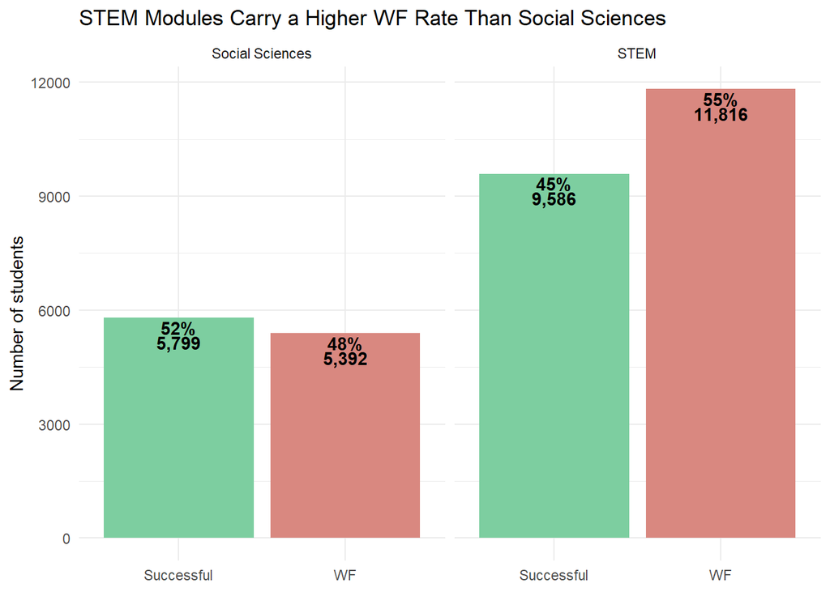

```r
# --- Visualize WF rate by domain ---
#_______________________________________________________________________________
# --- Visualize WF rate by domain ---
# WF by domain — annotated, dodged, counts on y
domain_outcomes <- oulad |>
  count(domain, wf) |>                              # 4 rows: STEM/WF, STEM/Successful, SS/WF, SS/Successful
  group_by(domain) |>                               # group by domain so percents are within domain
  mutate(pct = n / sum(n)) |>                       # add proportion column (sums to 100% per domain)
  ungroup()                                         # drop the grouping for cleaner downstream use


domain_outcomes |>
  ggplot(aes(x = wf, y = n, fill = wf)) +
  geom_col(show.legend = FALSE) +
  geom_text(aes(label = scales::comma(n)),
            vjust = 2.3, fontface = "bold") +
  geom_text(aes(label = scales::percent(pct, accuracy = 1)),
            vjust = 1.2, fontface = "bold") +
  facet_wrap(~ domain) +
  scale_fill_manual(values = c(
    "Successful" = "#7dcea0",
    "WF"         = "#d98880"
  )) +
  labs(
    title = "STEM Modules Carry a Higher WF Rate Than Social Sciences",
    x = NULL,
    y = "Number of students"
  ) +
  theme_minimal()
```

## 5.4 WF Rate by Course

Breaking the domain-level finding down to individual modules confirms that the pattern is not driven by a single outlier course as three of the four STEM modules (CCC, DDD, FFF) cluster at the top with WF rates between 53% and 62%. BBB is the notable exception as a Social Sciences module whose 53% WF rate places it alongside the STEM modules with the highest WF rates. AAA stands out as the module with the lowest WF rate of just 29% which is less than half that of CCC. The two remaining Social Sciences modules (GGG and AAA) anchor the bottom of the chart, suggesting that lower WF rates are generally a Social Sciences pattern rather than a universal one. EEE is the one STEM module that bucks the trend, sitting closer to the Social Sciences cluster at 44%.

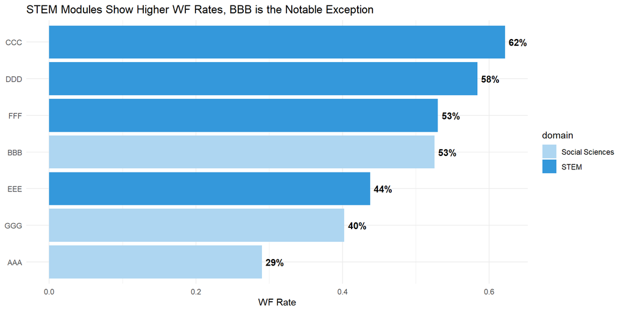

```r
module_wf <- oulad |>
  group_by(domain, code_module) |>
  summarise(
    wf_rate = mean(wf == "WF", na.rm = TRUE),
    .groups = "drop"
  )

module_wf |>
  ggplot(aes(x = reorder(code_module, wf_rate),
             y = wf_rate,
             fill = domain)) +
  geom_col() +
  geom_text(aes(label = scales::percent(wf_rate, accuracy = 1)),
            hjust = -0.2, fontface = "bold") +
  coord_flip() +
  scale_fill_manual(values = c(
    "STEM"            = "#3498db",
    "Social Sciences" = "#aed6f1"
  )) +
  labs(
    title = "STEM Modules Show Higher WF Rates, BBB is the Notable Exception",
    x = NULL,
    y = "WF Rate"
  ) +
  theme_minimal()
```

## 5.5 WF Rates Gender

Male students have a slightly higher WF rate than female students — 54% (9,619 enrollments) compared to 52% (7,589 enrollments). The two percentage point gap is modest and unlikely to be a primary driver of the overall WF pattern, but it is worth noting given that STEM enrollments skew more male. This raises the possibility that part of the STEM/Social Sciences WF gap may partly reflect the gender composition of each domain rather than course difficulty alone.

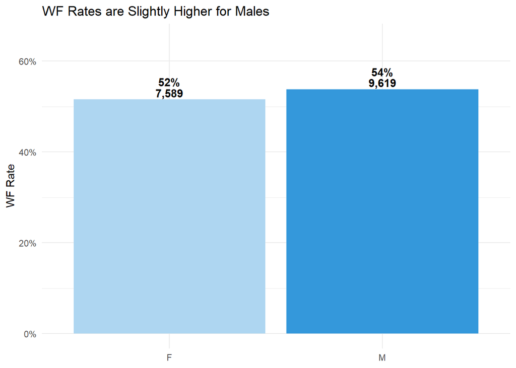

```r
gender_wf <- oulad |>
  count(gender, wf) |>                              # one row per gender/outcome combo
  group_by(gender) |>                               # group so percents calc within each gender
  mutate(pct = n / sum(n)) |>                       # proportion within gender (sums to 100% per gender)
  filter(wf == "WF") |>                             # keep only WF rows — one row per gender
  ungroup()                                         # drop grouping for cleaner downstream use

gender_wf |>
  ggplot(aes(x = gender, y = pct, fill = gender)) +
  geom_col(show.legend = FALSE) +
  geom_text(aes(label = scales::percent(pct, accuracy = 1)),
            vjust = -1.6, fontface = "bold") +
  geom_text(aes(label = scales::comma(n)),
            vjust = -0.3, fontface = "bold") +
  scale_y_continuous(labels = scales::percent, limits = c(0, 0.65)) +
  scale_fill_manual(values = c(
    "M" = "#3498db",
    "F" = "#aed6f1"
  )) +
  labs(
    title = "WF Rates are Slightly Higher for Males",
    x = NULL,
    y = "WF Rate"
  ) +
  theme_minimal()
```

## 5.6 WF Rates by Age

Contrary to what might be expected, younger students in the 0-35 age band show the highest WF rate at 55% — meaning 55% of all module enrollments by students in this age group ended in withdrawal or failure rather than a pass or distinction. WF rates drop steadily with age, falling to 48% for the 35-55 band and 38% for students 55 and older. This pattern likely reflects the life circumstances of older distance learners — students who choose to enroll later in life may be more intentional about their studies and better equipped to manage the demands of self-directed learning. The small number of WF enrollments in the 55+ group (83) means that finding should be interpreted cautiously — it represents a much smaller pool of students than the other two bands.

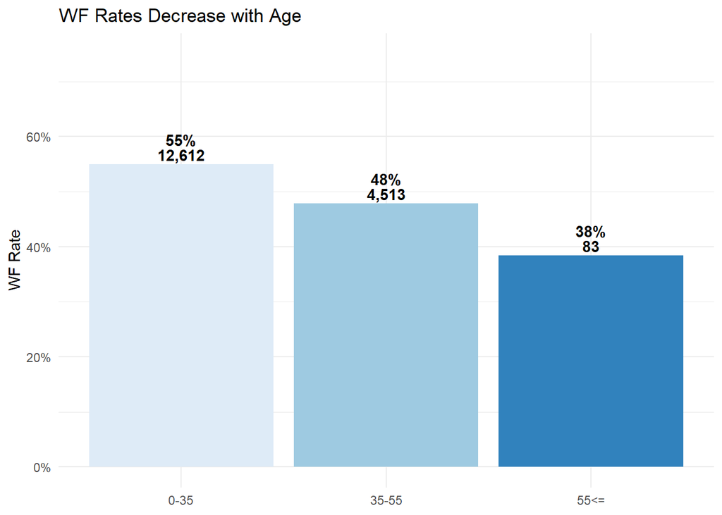

```r
# WF rate by age band
# count(age_band, wf) creates one row per age band/outcome combination
# group_by(age_band) means pct is calculated within each age band
# filter(wf == "WF") keeps only the WF rows — one bar per age band
age_wf <- oulad |>
  count(age_band, wf) |>                            # one row per age band/outcome combo
  group_by(age_band) |>                             # group so percents calc within each age band
  mutate(pct = n / sum(n)) |>                       # proportion within age band (sums to 100% per band)
  filter(wf == "WF") |>                             # keep only WF rows — one row per age band
  ungroup()                                         # drop grouping for cleaner downstream use

age_wf |>
  ggplot(aes(x = age_band, y = pct, fill = age_band)) +
  geom_col(show.legend = FALSE) +
  geom_text(aes(label = scales::percent(pct, accuracy = 1)),
            vjust = -1.6, fontface = "bold") +
  geom_text(aes(label = scales::comma(n)),
            vjust = -0.3, fontface = "bold") +
  scale_y_continuous(labels = scales::percent, limits = c(0, 0.75)) +
  scale_fill_brewer(palette = "Blues") +
  labs(
    title = "WF Rates Decrease with Age",
    x = NULL,
    y = "WF Rate"
  ) +
  theme_minimal()
```

## 5.7 WF Rates by IMD

The line chart above plots WF rates across each IMD band, where each point represents the proportion of enrollments in that band that ended in withdrawal or failure. The downward trend is clear and consistent — students from the most deprived areas (0-10% band) have a WF rate of 65%, dropping steadily to 42% for students from the least deprived areas (90-100% band). That is a 23 percentage point gap driven entirely by socioeconomic circumstance rather than academic domain.

The trend is nearly monotonic with only a minor plateau between the 30-50% bands, suggesting that socioeconomic deprivation has a steady cumulative relationship with non-completion rather than a sharp threshold effect. Each step up the deprivation scale is associated with a meaningful increase in WF risk. This finding raises important questions about whether the institution is providing adequate support for students from deprived backgrounds, and whether the STEM/Social Sciences WF gap we observed earlier may be partly explained by differences in the socioeconomic profiles of students who enroll in each domain.

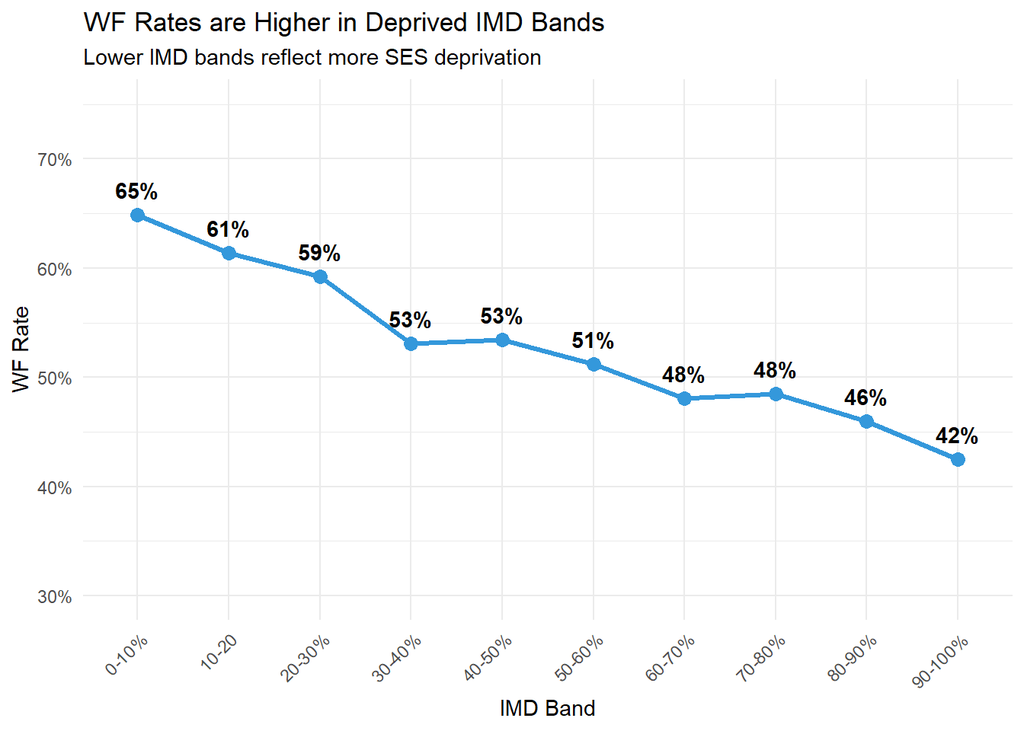

```r
# precompute WF rate per IMD band
imd_wf <- oulad |>
  filter(!is.na(imd_band)) |>                       # exclude 1,111 students missing IMD data
  count(imd_band, wf) |>                            # one row per IMD band/outcome combo
  group_by(imd_band) |>                             # group so percents calc within each band
  mutate(pct = n / sum(n)) |>                       # proportion within band
  filter(wf == "WF") |>                             # keep only WF rows — one row per band
  ungroup()                                         # drop grouping

imd_wf |>
  ggplot(aes(x = imd_band, y = pct, group = 1)) +
  geom_line(color = "#3498db", linewidth = 1.2) +
  geom_point(color = "#3498db", size = 3) +
  geom_text(aes(label = scales::percent(pct, accuracy = 1)),
            vjust = -1, fontface = "bold") +
  scale_y_continuous(labels = scales::percent, limits = c(0.3, 0.75)) +
  labs(
    title    = "WF Rates are Higher in Deprived IMD Bands",
    subtitle = "Lower IMD bands reflect more SES deprivation",
    x        = "IMD Band",
    y        = "WF Rate"
  ) +
  theme_minimal() +
  theme(axis.text.x = element_text(angle = 45, hjust = 1))
```

## 5.8 WF by Engagement and Assessment Scores

The scatterplot plots each student’s total VLE clicks (log scale) against their average assessment score, colored by outcome. Two patterns stand out. First, successful students (green) cluster in the upper right showing higher engagement and higher scores. WF students (red) are concentrated in the lower left, with fewer clicks and lower scores. Second, there is a interesting band of WF students scoring near zero across many engagement levels, perhaps representing students who submitted assessments but performed very poorly regardless of how much they interacted with course materials.

The log scale on the x axis is important context — the axis runs from 1 to 10,000+ clicks, meaning each gridline represents a tenfold increase in engagement rather than a fixed increment. A student at 1,000 clicks engaged ten times more than a student at 100 clicks, not ten clicks more. This compression is necessary because a small number of highly engaged students would otherwise stretch the axis and make the majority of student observations unreadable.

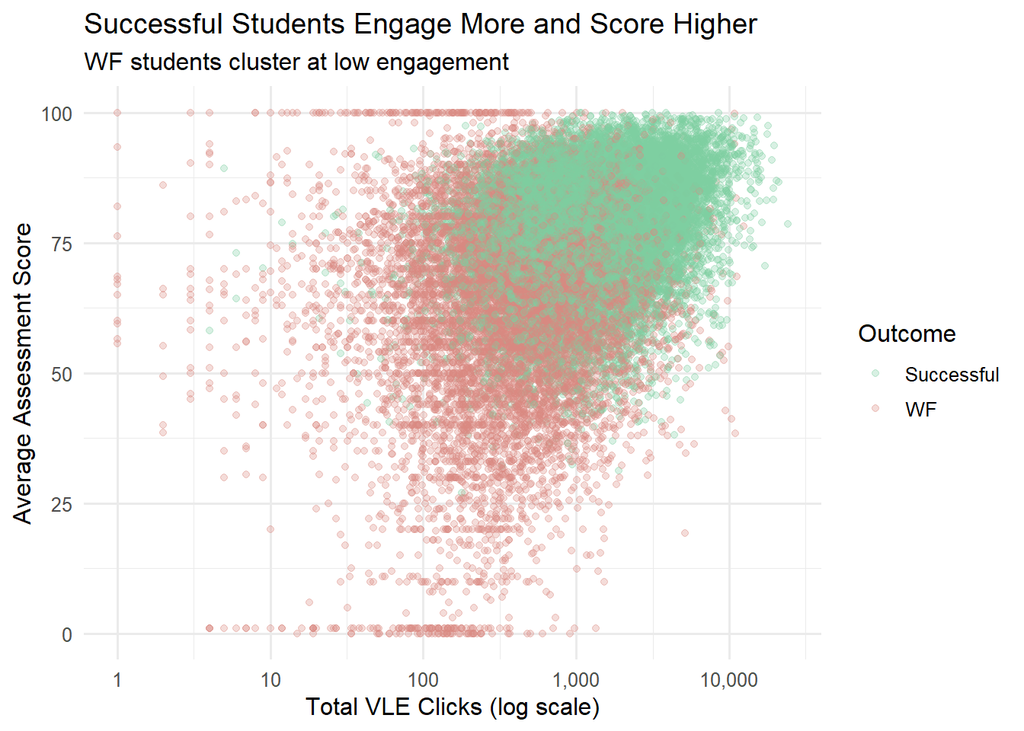

```r
# --- Why log scale on x? ---
# total_clicks ranges from 1 to ~50,000 across students
# a small number of very high-engagement students create extreme outliers
# on a linear scale those outliers stretch the x axis so far right that
# the majority of students get compressed into an unreadable pile on the left
# scale_x_log10() compresses the axis so each step is a multiplication by 10
# rather than a fixed addition — 1, 10, 100, 1000, 10000
# this spreads the points evenly and makes the relationship visible

oulad |>
  filter(
    !is.na(avg_score),      # exclude students with no recorded assessment scores
    !is.na(total_clicks)    # exclude students with no VLE interactions
  ) |>
  ggplot(aes(
    x     = total_clicks,   # VLE engagement on x axis
    y     = avg_score,      # assessment performance on y axis
    color = wf              # color points by outcome — WF vs Successful
  )) +
  geom_point(alpha = 0.3) + # alpha = 0.3 makes points semi-transparent
  # essential with 32k points — without it everything
  # overlaps into a solid unreadable mass
  scale_x_log10(labels = scales::comma) +  # log scale — see rationale above
  scale_color_manual(values = c(
    "WF"         = "#d98880",
    "Successful" = "#7dcea0"
  )) +
  labs(
    title   = "Successful Students Engage More and Score Higher",
    subtitle = "WF students cluster at low engagement",
    x       = "Total VLE Clicks (log scale)",
    y       = "Average Assessment Score",
    color   = "Outcome"
  ) +
  theme_minimal(base_size = 12)
```

## 5.9 Results

**Point 2 — Demographic risk is concentrated and predictable.** Students from the most deprived IMD bands face WF rates above 60% compared to 42% for the least deprived — a 23 percentage point gap driven by socioeconomic circumstance. Younger students in the 0-35 band show the highest WF rates at 55%, dropping to 38% for students 55 and older. Gender differences are modest at two percentage points. These patterns identify clear subpopulations where targeted early intervention would have the greatest impact.

**Point 3 — Disengagement is a detectable early signal.** Students who withdrew or failed engaged substantially less with course materials and scored lower on assessments than students who completed successfully. The separation between WF and Successful students is visible in VLE engagement data — suggesting that institutions with access to real-time learning analytics could identify at-risk students early enough to intervene before withdrawal occurs.

The evidence across all three dimensions points in the same direction. The case for targeted reallocation of academic support resources is supported by the data.

### 5.9.1 Summary Table

```r
# Step 1 — build the summary tibble with columns
findings_summary <- tibble(
  group = c( #column 1
    "Overall",
    "Overall",
    "Point 1 — Domain Gap",
    "Point 1 — Domain Gap",
    "Point 2 — SES Background (IMD Band)",
    "Point 2 — SES Background (IMD Band)",
    "Point 2 — Age Band",
    "Point 2 — Age Band",
    "Point 2 — Gender",
    "Point 2 — Gender",
    "Point 3 — VLE Engagement (Median VLE Clicks)",
    "Point 3 — VLE Engagement (Median VLE Clicks)"
  ),
  finding = c( #column 2
    "Overall WF Rate", #overall group
    "Overall Successful Rate",
    "STEM", #domain group
    "Social Sciences",
    "Most Deprived (0-10%)", #age group
    "Least Deprived (90-100%)",
    "Age 0-35",
    "Age 55+",
    "Male", #gender
    "Female",
    "Successful Students",#vle
    "WF Students"
  ),
  rate = c(
    "53%", "47%",
    "55%", "48%",
    "65%", "42%",
    "55%", "38%",
    "54%", "52%",
    "1,425 clicks", "280 clicks"
  ),
  gap = c(
    "6%", "",
    "7%", "",
    "23%", "",
    "17%", "",
    "2%", "",
    "80%", ""
  )
)


# Step 2 — pass the summary to gt with a single groupname_col argument
findings_summary |>
  gt(groupname_col = "group") |>
  cols_label(
    finding = "Metric", #new column names for the resulting table
    rate    = "Rate",
    gap     = "Gap"
  ) |>
  tab_style(
    style     = cell_text(weight = "bold"),
    locations = cells_column_labels()
  ) |>
  tab_style(
    style     = cell_fill(color = "#d6eaf8"),
    locations = cells_row_groups()
  ) |>
  tab_style(
    style     = cell_text(weight = "bold"),
    locations = cells_body(columns = gap)
  ) |>
  tab_options(
    table.align                     = "left",
    row.striping.include_table_body = FALSE, #prevent qmd default styling
    quarto.disable_processing       = TRUE
  )
```

| Metric | Rate | Gap |
| --- | --- | --- |
| Overall |  |  |
| Overall WF Rate | 53% | 6% |
| Overall Successful Rate | 47% |  |
| Point 1 — Domain Gap |  |  |
| STEM | 55% | 7% |
| Social Sciences | 48% |  |
| Point 2 — SES Background (IMD Band) |  |  |
| Most Deprived (0-10%) | 65% | 23% |
| Least Deprived (90-100%) | 42% |  |
| Point 2 — Age Band |  |  |
| Age 0-35 | 55% | 17% |
| Age 55+ | 38% |  |
| Point 2 — Gender |  |  |
| Male | 54% | 2% |
| Female | 52% |  |
| Point 3 — VLE Engagement (Median VLE Clicks) |  |  |
| Successful Students | 1,425 clicks | 80% |
| WF Students | 280 clicks |  |

# 6 Interpretation

## 6.1 What the Results Mean

The table in this section considers the WF rate evidence in dollar terms, showing what a risk-weighted reallocation of academic support resources would look like across three dimensions: course domain, socioeconomic background, and age band. Each column tells part of the story.

**WF Rate** is the proportion of enrollments in each group that ended in withdrawal or failure — the core evidence driving the reallocation case. **Enrollments** shows the size of each group, which determines the total budget impact of any per-enrollment change. **Current $/Enrollment** is what each group currently receives in support funding per enrolled student. **Proposed $/Enrollment** is what a risk-weighted allocation would look like — higher WF rate groups receive more per student, lower WF rate groups receive less. **Funding Gap** is the net dollar difference between current and proposed total spending for each group — green cells indicate groups that would receive more funding, red cells indicate groups where spending would decrease to fund the increases elsewhere.

**By Domain**, the reallocation is straightforward. STEM students — who withdraw or fail at a 55% rate compared to 48% in Social Sciences — would see per-enrollment support rise from $84 to $120, generating an additional $770,472 in annual support investment. Social Sciences funding would decrease by $246,202 under this model, reflecting the lower WF risk of that population.

**By Age Band**, younger students in the 0-35 group carry the highest WF rate at 55% but currently receive the least support per enrollment at $88. A risk-weighted allocation would raise that to $115, an additional $445,500 annually. Students aged 35-55 and 55+ would see modest reductions, though the 55+ group is small enough (3,293 enrollments) that the dollar impact of any change is limited.

Taken together, the table makes a clear case for additional investment across three independent dimensions of student risk. If each dimension is funded separately — recognizing that a high-risk student may benefit from support targeted at their domain, their socioeconomic background, and their age group simultaneously — the total net new ask across all three dimensions is $1,668,372 annually. This is not a reallocation of existing resources. It is a proposal to invest in the students the data identifies as most at risk, across every dimension where that risk is measurable. The cost of inaction — continued high WF rates, lost tuition, and interrupted student trajectories — is currently borne by students. The cost of action is $1,668,372.

```r
#_______________________________________________________________________________
# Current vs Proposed Allocation ---
# shows the funding gap between what groups currently receive
# and what the WF evidence suggests they should receive
# numbers are illustrative — replace with actual institutional figures

#| label: interpretation-table
tibble(
  group              = c(
    "STEM",
    "Social Sciences",
    "IMD 0-30% (Most Deprived)",
    "IMD 30-70% (Middle)",
    "IMD 70-100% (Least Deprived)",
    "Age 0-35",
    "Age 35-55",
    "Age 55+"
  ),
  wf_rate            = c(0.55, 0.48, 0.62, 0.52, 0.44, 0.55, 0.48, 0.38),
  enrollments        = c(21402, 11191, 9200, 12800, 9400, 16500, 12800, 3293),
  current_per_enroll  = c(84, 107, 90, 92, 94, 88, 96, 104),
  proposed_per_enroll = c(120, 85, 135, 95, 75, 115, 90, 80)
) |>
  mutate(
    current_total  = enrollments * current_per_enroll,
    proposed_total = enrollments * proposed_per_enroll,
    gap            = proposed_total - current_total
  ) |>
  gt() |>
  cols_label(
    group               = "Group",
    wf_rate             = "WF Rate",
    enrollments         = "Enrollments",
    current_per_enroll  = "Current $/Enrollment",
    proposed_per_enroll = "Proposed $/Enrollment",
    current_total       = "Current Total",
    proposed_total      = "Proposed Total",
    gap                 = "Funding Gap"
  ) |>
  fmt_percent(columns = wf_rate, decimals = 0) |>
  fmt_number(columns = enrollments, decimals = 0) |>
  fmt_currency(columns = c(current_per_enroll, proposed_per_enroll,
                            current_total, proposed_total, gap),
               currency   = "USD",
               decimals   = 0,
               accounting = TRUE) |>
  tab_header(
    title    = "Current vs Proposed Resource Allocation by Risk Group",
    subtitle = "Proposed allocation weighted by WF rate — higher risk groups receive more per enrollment"
  ) |>
  # grand summary rows showing totals per section
  grand_summary_rows(
    columns = c(current_total, proposed_total, gap),
    fns     = list(
      `Total Net Ask` = ~ sum(.[gap > 0], na.rm = TRUE)  # sum only increases
    ),
    fmt = ~ fmt_currency(., currency = "USD", decimals = 0, accounting = TRUE)
  ) |>
  tab_style(
    style     = cell_text(weight = "bold"),
    locations = cells_column_labels()
  ) |>
  tab_style(
    style     = cell_fill(color = "white"),
    locations = cells_body(columns = -gap)
  ) |>
  tab_style(
    style     = cell_fill(color = "#7dcea0"),
    locations = cells_body(columns = gap, rows = gap > 0)
  ) |>
  tab_style(
    style     = cell_fill(color = "#d98880"),
    locations = cells_body(columns = gap, rows = gap < 0)
  ) |>
  tab_row_group(label = "By Age Band",  rows = 6:8) |>
  tab_row_group(label = "By IMD Band",  rows = 3:5) |>
  tab_row_group(label = "By Domain",    rows = 1:2) |>
  tab_style(
    style     = cell_fill(color = "#d6eaf8"),
    locations = cells_row_groups()
  ) |>
  tab_options(
    table.align                     = "left",
    row.striping.include_table_body = FALSE,
    quarto.disable_processing       = TRUE
  )
```

Current vs Proposed Resource Allocation by Risk Group

Proposed allocation weighted by WF rate — higher risk groups receive more per enrollment

|  | Group | WF Rate | Enrollments | Current $/Enrollment | Proposed $/Enrollment | Current Total | Proposed Total | Funding Gap |
| --- | --- | --- | --- | --- | --- | --- | --- | --- |
| By Domain |  |  |  |  |  |  |  |  |
|  | STEM | 55% | 21,402 | $84 | $120 | $1,797,768 | $2,568,240 | $770,472 |
|  | Social Sciences | 48% | 11,191 | $107 | $85 | $1,197,437 | $951,235 | ($246,202) |
| By IMD Band |  |  |  |  |  |  |  |  |
|  | IMD 0-30% (Most Deprived) | 62% | 9,200 | $90 | $135 | $828,000 | $1,242,000 | $414,000 |
|  | IMD 30-70% (Middle) | 52% | 12,800 | $92 | $95 | $1,177,600 | $1,216,000 | $38,400 |
|  | IMD 70-100% (Least Deprived) | 44% | 9,400 | $94 | $75 | $883,600 | $705,000 | ($178,600) |
| By Age Band |  |  |  |  |  |  |  |  |
|  | Age 0-35 | 55% | 16,500 | $88 | $115 | $1,452,000 | $1,897,500 | $445,500 |
|  | Age 35-55 | 48% | 12,800 | $96 | $90 | $1,228,800 | $1,152,000 | ($76,800) |
|  | Age 55+ | 38% | 3,293 | $104 | $80 | $342,472 | $263,440 | ($79,032) |
| Total Net Ask | — | — | — | — | — | $5,255,368 | $6,923,740 | $1,668,372 |

## 6.2 Recommendations

The evidence presented in this proposal supports a targeted increase in academic support investment directed at the student populations where WF risk is highest and current resources are most misaligned. We propose five initiatives totaling $1,668,372 in net new annual funding, each grounded directly in the findings of this analysis.

**Early Alert System — VLE Monitoring ($300,000 net new)** Our data shows that WF students engage with course materials at a fraction of the rate of successful students — a median of 280 clicks compared to 1,425 for students who complete. This signal is detectable early in the module and currently goes unacted upon. We propose investing in an early alert system that flags low-engagement students to academic advisors in real time, enabling proactive outreach before withdrawal becomes likely. This initiative targets all 32,593 enrollments and has no current funding.

**STEM Advising Capacity Expansion ($305,000 net new)** STEM enrollments represent 65% of our total student body but advising capacity has not kept pace with that proportion. This investment expands dedicated advising hours for STEM students, ensuring that academic guidance is available at the scale the enrollment data demands.

**At-Risk Student Intervention Pilot ($148,372 net new)** The overlap between STEM enrollment and high deprivation is the highest concentration of WF risk in our dataset. This pilot funds a structured early intervention program for students sitting at the intersection of both risk factors — tested at small scale in the first year with a clear evaluation framework to assess impact before broader rollout.

```r
# --- The Funding Ask ---
# net new ask = $524,270 based on domain-level reallocation analysis
# initiatives below are sized to match that total
tibble(
  initiative       = c(
    "STEM Dedicated Tutoring Program",
    "Early Alert System — VLE Monitoring",
    "High Deprivation Student Support Fund",
    "STEM Advising Capacity Expansion",
    "At-Risk Student Intervention Pilot"
  ),
  rationale        = c(
    "STEM WF rate 7pp above Social Sciences across all 4 modules",
    "WF students show detectable low engagement before withdrawal",
    "IMD 0-30% students face 65% WF rate vs 42% for least deprived",
    "STEM enrollment is 65% of total but advising hours are not proportional",
    "Test structured early intervention with highest-risk cohort"
  ),
  target_group     = c(
    "STEM enrollments (21,402)",
    "All enrollments (32,593)",
    "IMD 0-30% enrollments (9,200)",
    "STEM enrollments (21,402)",
    "STEM + IMD 0-30% overlap"
  ),
  current_funding  = c(150000, 0, 85000, 45000, 0),
  requested        = c(700000, 300000, 450000, 350000, 148372)
  # requested totals are sized so net new = $1,668,372
) |>
  mutate(additional = requested - current_funding) |>
  gt() |>
  cols_label(
    initiative      = "Initiative",
    rationale       = "Evidence Base",
    target_group    = "Target Population",
    current_funding = "Current Funding",
    requested       = "Requested",
    additional      = "Net New Ask"
  ) |>
  fmt_currency(columns = c(current_funding, requested, additional),
               currency = "USD",
               decimals = 0) |>
  tab_header(
    title    = "Proposed Academic Support Investments",
    subtitle = "Total net new funding request: $1,668,372 annually"
  ) |>
  tab_style(
    style     = cell_fill(color = "#7dcea0"),   # green — net new ask
    locations = cells_body(columns = additional)
  ) |>
  tab_style(
    style     = cell_text(weight = "bold"),
    locations = cells_column_labels()
  ) |>
  tab_style(
    style     = cell_fill(color = "white"),
    locations = cells_body(columns = -additional)
  ) |>
  grand_summary_rows(
    columns  = c(current_funding, requested, additional),
    fns      = list(Total = ~sum(.)),
    fmt      = ~ fmt_currency(., currency = "USD", decimals = 0)
  ) |>
  tab_options(
    table.align                     = "left",
    row.striping.include_table_body = FALSE,
    quarto.disable_processing       = TRUE
  )
```

Proposed Academic Support Investments

Total net new funding request: $1,668,372 annually

[output not shown]

# 7 Limitations

This analysis is descriptive rather than causal. The patterns we have documented — higher WF rates in STEM, elevated risk among deprived and younger students, lower engagement among students who withdraw — are consistent and meaningful, but they do not allow us to conclude that domain, deprivation, or age are the exclusive cause of withdrawal. Other factors not captured in our data may explain part or all of the observed gaps.

The funding figures presented are illustrative. Current per-enrollment support costs are estimated rather than drawn from a formal budget audit, and the proposed allocations are modeled rather than costed. A full budget analysis would be required before any reallocation decision is made.

The dataset covers data from previous terms. Student demographics, module structures, and institutional support arrangements may have changed since that period. We recommend validating the key WF rate patterns against current enrollment data before committing to specific investment levels.

The IMD band data is missing for 1,111 students — primarily those living outside England — which means the socioeconomic analysis could understates the full picture for that population. International and non-English students may face distinct risk factors not captured by IMD alone.

Finally, the analysis treats all WF outcomes equivalently. A student who withdraws in week two and a student who fails a final exam after completing all coursework are both counted as WF — but they represent very different support needs and very different points of intervention. A more granular analysis of withdrawal timing and failure type could strengthen the targeting of any intervention program.

# 8 Appendix

**Appendix B: Full Analysis Code**

```r
#### Setup ####
library(tidyverse)
library(Amelia) #To visualize missingness
library(gt)       #fancy tables
library(gtExtras) #fancier tables.
library(scales)

# --- Load all tables ---
student_info         <- read_csv("studentInfo.csv")
student_registration <- read_csv("studentRegistration.csv")
student_assessment   <- read_csv("studentAssessment.csv")
student_vle          <- read_csv("studentVle.csv")
assessments          <- read_csv("assessments.csv")
courses              <- read_csv("courses.csv")
vle                  <- read_csv("vle.csv")


#>The Open University Learning Analytics Dataset (OULAD) is a publicly available
#>dataset containing anonymized student data from the UK's Open University,
#>covering 22 module presentations across 7 courses from 2013 and 2014. It
#>includes demographic information, assessment results, and detailed Virtual
#>Learning Environment interaction logs for 32,593 students,

#_______________________________________________________________________________
#_______________________________________________________________________________
# OULAD VARIABLE REFERENCE
#_______________________________________________________________________________

# --- studentInfo ---
# One row per student per module-presentation. Central table of the dataset —
# contains student demographics and their final result for each module taken.
# code_module          — module identifier. Real module names were replaced with
#                        letter codes (AAA, BBB, CCC, DDD, EEE,
#                        FFF, GGG) to preserve anonymity. AAA, BBB and GGG are
#                        Social Sciences modules; CCC, DDD, EEE and FFF are STEM.
# code_presentation    — identifies when the module ran. The letter suffix
#                        indicates the start month — J = October, B = February.
#                        The number is the year. So "2013J" started October 2013
#                        and "2014B" started February 2014.
# id_student           — unique student ID (randomized during anonymization —
#                        does not correspond to any real OU student number)
# gender               — student gender
# region               — UK region where student lived during the module
# highest_education    — highest qualification on entry
# imd_band             — Index of Multiple Deprivation band of student's home
#                        area. A measure of socioeconomic disadvantage based on
#                        postcode — lower band = more deprived area.
# age_band             — banded age group (not exact age — generalized during
#                        anonymization to protect student identity)
# num_of_prev_attempts — how many times student previously attempted this module
# studied_credits      — total credits student is studying concurrently
# disability           — whether student declared a disability
# final_result         — Pass / Fail / Distinction / Withdrawn
#____________________________


# --- studentRegistration ---
# One row per student per module-presentation. Records when the student
# signed up and, if applicable, when they dropped out.
# date_registration    — day student registered, expressed as days relative to
#                        the module start date (negative = registered early)
# date_unregistration  — day student unregistered (empty if they completed)
#____________________________


# --- studentAssessment ---
# One row per student per assessment submitted. Records the score and
# submission date for each individual assessment a student handed in.
# id_assessment        — links to assessments table
# date_submitted       — day assessment was submitted, relative to module start
# is_banked            — result carried over from a previous presentation
#                        (student gets credit without resubmitting)
# score                — 0-100, below 40 is a Fail
#____________________________


# --- assessments ---
# One row per assessment. The catalog of all assessments across all modules
# and presentations — metadata about what each assessment is, not who took it.
# id_assessment        — unique assessment identifier
# assessment_type      — TMA (Tutor Marked Assessment — marked by a human tutor),
#                        CMA (Computer Marked Assessment — auto-graded), or
#                        Exam (final exam at end of module)
# date                 — assessment cut-off day, relative to module start
# weight               — percentage weight of this assessment. Exams are treated
#                        separately at 100%; all other assessments sum to 100%.
#____________________________


# --- courses ---
# One row per module-presentation. Contains structural information about
# each module offering — primarily its length.
# length               — module duration in days from start date to end date
#____________________________

# --- studentVle ---
# One row per student per material per day. The raw interaction log —
# 10 million rows recording every click a student made in the VLE.
# id_site              — links to vle table (identifies the specific material)
# date                 — day of interaction, relative to module start
# sum_click            — number of clicks on that material that day
#____________________________


# --- vle ---
# One row per VLE material. The catalog of all learning materials available
# across all modules — metadata about what each material is, not who used it.
# id_site              — unique material identifier
# activity_type        — type of VLE material (e.g. resource, quiz, forum,
#                        oucontent, url, page, subpage, glossary, etc.)
# week_from            — week material is planned to become available
# week_to              — week material is planned to stop being used
#_______________________________________________________________________________


#_______________________________________________________________________________
# VARIABLES CREATED
#_______________________________________________________________________________
```

```r
# --- domain ---
# Derived from code_module. Groups the 7 anonymized module codes into their
# subject area as documented in the OULAD paper.
# Social Sciences — AAA, BBB, GGG
# STEM            — CCC, DDD, EEE, FFF

# --- wf ---
# Withdrawal and Failure flag. Collapses final_result into a binary outcome
# for non-completion analysis. D grades do not exist in the OU system so
# DWF reduces to WF here.
# WF         — Withdrawn or Fail (did not successfully complete)
# Successful — Pass or Distinction (successfully completed)

# --- avg_score ---
# Mean assessment score across all submitted assessments for the student
# in that module. Excludes missing scores (na.rm = TRUE).

# --- min_score ---
# Lowest individual assessment score submitted by the student in that module.

# --- max_score ---
# Highest individual assessment score submitted by the student in that module.

# --- n_assessments ---
# Count of assessments with a recorded score. Uses sum(!is.na(score)) rather
# than n() to avoid inflating the count with missing exam scores.

# --- n_failed ---
# Count of assessments where score < 40. Per OULAD documentation, a score
# below 40 is interpreted as a Fail.

# --- avg_days_early ---
# Mean difference between assessment due date and submission date across all
# assessments. Positive = submitted early, negative = submitted late.

# --- total_clicks ---
# Total number of VLE clicks recorded for the student across the whole module.
# Students with no VLE interactions have NA here (3,365 students).

# --- total_days_active ---
# Number of distinct days the student interacted with the VLE.
# A measure of engagement consistency rather than volume.

# --- module_presentation_length ---
# Length of the module in days from start to end date, from the courses table.
#_______________________________________________________________________________








#### Pre-Join Inspection ####
#_______________________________________________________________________________
# PRE-JOIN DATA INSPECTION
# Run these before joining to verify column names, key values and row counts
# so we can confirm the joins will behave as expected.
#_______________________________________________________________________________

# --- Row counts ---
# Tells us the size of each table before any joining
nrow(student_info)
nrow(student_registration)
nrow(student_assessment) #number of student assessment submissions
nrow(assessments) #number of total assessments
nrow(courses)
nrow(student_vle)#The click events that exists in the VLE.
nrow(vle) #The material that exists in the VLE.

# --- Column names ---
# Verify the join keys exist and are named consistently across tables
names(student_info)
names(student_registration)
names(student_assessment)
names(assessments)
names(courses)
names(student_vle)
names(vle)

# --- Check the key columns match across tables ---
# id_student values should overlap between student_info and student_registration
n_distinct(student_info$id_student)
n_distinct(student_registration$id_student)

# match between id_assessment  studentAssessment and assessments?
n_distinct(student_assessment$id_assessment)
n_distinct(assessments$id_assessment)

# match between student_vle and vle id_site?
n_distinct(student_vle$id_site)
n_distinct(vle$id_site) #96n discrepency means some things werent clicked likely.

# --- Check the composite key is actually unique in student_info ---
# If this number equals nrow(student_info) each combination is unique
student_info |>
  distinct(id_student, code_module, code_presentation) |>
  nrow() #does match

# --- Spot check a few rows of each table ---
head(student_info)
head(student_registration)
head(student_assessment)
head(assessments)
head(courses)
head(student_vle)
head(vle)



# --- Missing value counts per table before joining ---
# Check each raw table independently so we know what missingness
# exists in the source data before any joins are performed.

#--- Takeaway ---
# The join keys themselves are all clean —
# no missing values in id_student, code_module, code_presentation, id_assessment,
# or id_site in any table. That's the main thing to verify before joining.
colSums(is.na(student_info))
colSums(is.na(student_registration))
colSums(is.na(student_assessment))
colSums(is.na(assessments))
colSums(is.na(courses))
colSums(is.na(student_vle))
colSums(is.na(vle))









#### Pre-Join Vars ####
#____________________________
#left_join keeps all rows from the left table and attaches
# matching columns from the right. Where no match exists the right columns
# come back as NA — no students accidentally dropped.
#____________________________



# --- Enrich studentAssessment with module context before joining ---
# studentAssessment only has id_assessment and id_student — no module info.
# assessments has the module context (code_module, code_presentation, type,
# due date, weight) linked via id_assessment.
# We join them together first so the enriched table can then join cleanly
# to student_info on all three keys without a many-to-many explosion.
student_assessment_enriched <- student_assessment |>
  left_join(assessments, by = "id_assessment")

glimpse(student_assessment_enriched)






# --- Summarise studentAssessment before joining ---
# Collapses to one row per student per module — keeps the final table at
# student level (32,593 rows). Rows with no recorded score are filtered
# out first to avoid Inf from min/max on all-NA groups. Students with no
# submissions still appear in the final table via the left join as NA.
assessment_summary <- student_assessment_enriched |>
  filter(!is.na(score)) |> #filter() keeps rows where the condition is TRUE
                           #this keeps rows where score is not missing
  group_by(id_student, code_module, code_presentation) |>
  summarise(
    avg_score      = mean(score, na.rm = TRUE),      # average across all assessments
    min_score      = min(score, na.rm = TRUE),       # worst assessment
    max_score      = max(score, na.rm = TRUE),       # best assessment
    n_assessments  = sum(!is.na(score)),             # count of scored assessments
    n_failed       = sum(score < 40, na.rm = TRUE),  # score < 40 = Fail per OULAD docs
    avg_days_early = mean(date - date_submitted,     # submission timing vs due date
                          na.rm = TRUE),
    .groups = "drop"
  )
```

```r
glimpse(assessment_summary)






# --- Summarise studentVle before joining ---
# studentVle has 10 million rows — joining it raw caused a many-to-many
# explosion and a memory error. Instead we pre-summarize it down to one
# row per student per module (total_clicks and total_days_active) so it
# matches the granularity of the rest of the table.
vle_summary <- student_vle |>
  group_by(id_student, code_module, code_presentation) |>
  summarise(
    total_clicks = sum(sum_click),        # total engagement
    total_days_active = n_distinct(date), # days they logged in
    .groups = "drop"
  )

glimpse(vle_summary)









#### Join ####


# --- Step 1: Start with student demographics ---
# student_info is the central table. Every subsequent join builds outward
# from here.
#Each record is an enrollment. One student can have many enrollments.
oulad_1 <- student_info

# inspect
glimpse(oulad_1)

# --- Step 2: Add registration dates ---
# When the student signed up and (if applicable) when they unregistered.
# Matched on student + module + presentation since the same student can
# take multiple modules and multiple presentations of the same module.
oulad_2 <- oulad_1 |>
  left_join(student_registration,
            by = c("id_student", "code_module", "code_presentation"))

# inspect
glimpse(oulad_2)

# --- Step 3: Add summarised assessment scores ---
# Uses assessment_summary rather than the raw enriched table so the data
# stays at one row per student — 32,593 rows throughout.
# Each student gets a single row of summary stats across all their
# assessments rather than one row per assessment submitted.
oulad_3 <- oulad_2 |>
  left_join(assessment_summary,
            by = c("id_student", "code_module", "code_presentation"))

# inspect
glimpse(oulad_3)

# --- Step 4: Add course/module info ---
# Primarily the length of the module in days from start date to end date.
oulad_4 <- oulad_3 |>
  left_join(courses,
            by = c("code_module", "code_presentation"))

# inspect
glimpse(oulad_4)

# --- Step 5: Add summarised VLE engagement ---
# Joins the pre-summarised VLE table — one row per student per module.
# total_clicks = overall engagement, total_days_active = consistency.
oulad_5 <- oulad_4 |>
  left_join(vle_summary,
            by = c("id_student", "code_module", "code_presentation"))

# inspect
glimpse(oulad_5)


# --- Final dataset ---
oulad <- oulad_5
glimpse(oulad)


# check missingness across all columns
oulad |>
  # for every column count the number of NA values
  # across() applies the function to every column
  # ~ sum(is.na(.)) — for each column, count how many values are NA
  summarise(across(everything(), ~ sum(is.na(.)))) |>
  glimpse()


#look for patterns of missing visually if helpful.
missmap(oulad)


# --- Add analytical variables ---
# domain groups modules into STEM and Social Sciences based on the
# module codes documented in the OULAD paper.
# wf flags students who did not successfully complete — Withdrawn or Fail
# combined into a single non-completion outcome. D grades don't exist
# in the OU system so DWF reduces to WF here.

#Check these variables we are interested in.
oulad |> distinct(code_module)
oulad |> distinct(final_result)


oulad <- oulad |>
  mutate(
    domain = case_when(
      code_module %in% c("AAA", "BBB", "GGG") ~ "Social Sciences",
      code_module %in% c("CCC", "DDD", "EEE", "FFF") ~ "STEM"
    ),
    wf = case_when(
      final_result %in% c("Withdrawn", "Fail") ~ "WF",
      final_result %in% c("Pass", "Distinction") ~ "Successful"
    )
  )

glimpse(oulad)


# verify domain and wf — any NA means a value wasn't caught by case_when
oulad |> count(domain)
oulad |> count(wf)


#### Load Data ####
# --- Export ---
write_csv(oulad, "oulad_clean.csv")

# --- Import ---
oulad <- read_csv("oulad_clean.csv")
















#### EDA ####
#_______________________________________________________________________________
# EXPLORATORY DATA ANALYSIS
#_______________________________________________________________________________

#_______________________________________________________________________________
# DESCRIPTIVE EDA — WHO ARE OUR STUDENTS?
#_______________________________________________________________________________

# --- Gender ---
oulad |>
  distinct(id_student, gender) |>    # one row per unique student
  count(gender) |>
  mutate(pct = n / sum(n))


# ---Gender visual starter ---
oulad |>
  distinct(id_student, gender) |>
  ggplot(aes(x = gender, fill = gender)) +
  geom_bar() +
  labs(
    title = "Student Body Skews Slightly Male",
    x = NULL,
    y = "Number of students"
  )


#________________________________________________________
# vertical adjustment:
# vjust = 1.5    label sits inside the top of the bar
# vjust = 1      label's top edge sits on bar's top edge
# vjust = 0.5    label centered on bar's top edge
# vjust = 0      label's bottom edge sits on bar's top edge
# vjust = -0.5   small gap above the bar
# vjust = -1.5   bigger gap above the bar
#________________________________________________________



# ---Gender hard-coded labels
oulad |>
  distinct(id_student, gender) |>
  ggplot(aes(x = gender, fill = gender)) +
  geom_bar() +
  annotate("text", x = "F", y = 13739, label = "13,739", vjust = -0.5) +
  annotate("text", x = "M", y = 15046, label = "15,046", vjust = -0.5) +
  labs(
    title = "Student Body Skews Slightly Male",
    x = NULL,
    y = "Number of students"
  )

# ---Gender hard-coded labels (count and percent)
oulad |>
  distinct(id_student, gender) |>
  ggplot(aes(x = gender, fill = gender)) +
  geom_bar() +
  annotate("text", x = "F", y = 13739, label = "13,739", vjust = -1.6) +
  annotate("text", x = "F", y = 13739, label = "(47.7%)", vjust = -0.3) +
  annotate("text", x = "M", y = 15046, label = "15,046", vjust = -1.2) +
  annotate("text", x = "M", y = 15046, label = "(52.3%)", vjust = 0.2) +
  labs(
    title = "Student Body Skews Slightly Male",
    x = NULL,
    y = "Number of students"
  )
```

```r
# ---Gender hard-coded w. color
oulad |>
  distinct(id_student, gender) |>
  ggplot(aes(x = gender, fill = gender)) +
  geom_bar() +
  annotate("text", x = "F", y = 13739, label = "13,739",  vjust = -1.6) +
  annotate("text", x = "F", y = 13739, label = "(47.7%)", vjust = -0.3) +
  annotate("text", x = "M", y = 15046, label = "15,046",  vjust = -1.0) +
  annotate("text", x = "M", y = 15046, label = "(52.3%)", vjust = .2) +
  scale_fill_manual(values = c("F" = "#aed6f1", "M" = "#3498db")) +
  labs(
    title = "Student Body Skews Slightly Male",
    x = NULL,
    y = "Number of students"
  )


# more granular counts
oulad |>
  distinct(id_student, gender) |>
  ggplot(aes(x = gender, fill = gender)) +
  geom_bar() +
  annotate("text", x = "F", y = 13739, label = "13,739",  vjust = -1.6) +
  annotate("text", x = "F", y = 13739, label = "(47.7%)", vjust = -0.3) +
  annotate("text", x = "M", y = 15046, label = "15,046",  vjust = -1.0) +
  annotate("text", x = "M", y = 15046, label = "(52.3%)", vjust =  0.2) +
  scale_y_continuous(breaks = seq(0, 16000, by = 2000)) +
  scale_fill_manual(values = c("F" = "#aed6f1", "M" = "#3498db")) +
  labs(
    title = "Student Body Skews Slightly Male",
    x = NULL,
    y = "Number of students"
  )



# bold the labels
oulad |>
  distinct(id_student, gender) |>
  ggplot(aes(x = gender, fill = gender)) +
  geom_bar() +
  annotate("text", x = "F", y = 13739, label = "13,739",  vjust = -1.6, fontface = "bold") +
  annotate("text", x = "F", y = 13739, label = "(47.7%)", vjust = -0.3, fontface = "bold") +
  annotate("text", x = "M", y = 15046, label = "15,046",  vjust = -1.0, fontface = "bold") +
  annotate("text", x = "M", y = 15046, label = "(52.3%)", vjust =  0.2, fontface = "bold") +
  scale_y_continuous(breaks = seq(0, 16000, by = 2000)) +
  scale_fill_manual(values = c("F" = "#aed6f1", "M" = "#3498db")) +
  labs(
    title = "Student Body Skews Slightly Male",
    x = NULL,
    y = "Number of students"
  )


# move the counts down on the bars
oulad |>
  distinct(id_student, gender) |>
  ggplot(aes(x = gender, fill = gender)) +
  geom_bar() +
  annotate("text", x = "F", y = 13739, label = "13,739",  vjust =  1.5, fontface = "bold") +
  annotate("text", x = "F", y = 13739, label = "(47.7%)", vjust =  3.0, fontface = "bold") +
  annotate("text", x = "M", y = 15046, label = "15,046",  vjust =  1.5, fontface = "bold") +
  annotate("text", x = "M", y = 15046, label = "(52.3%)", vjust =  3.0, fontface = "bold") +
  scale_y_continuous(breaks = seq(0, 16000, by = 2000)) +
  scale_fill_manual(values = c("F" = "#aed6f1", "M" = "#3498db")) +
  labs(
    title = "Student Body Skews Slightly Male",
    x = NULL,
    y = "Number of students"
  )


# remvove the gray background
oulad |>
  distinct(id_student, gender) |>
  ggplot(aes(x = gender, fill = gender)) +
  geom_bar() +
  annotate("text", x = "F", y = 13739, label = "13,739",  vjust =  1.5, fontface = "bold") +
  annotate("text", x = "F", y = 13739, label = "(47.7%)", vjust =  3.0, fontface = "bold") +
  annotate("text", x = "M", y = 15046, label = "15,046",  vjust =  1.5, fontface = "bold") +
  annotate("text", x = "M", y = 15046, label = "(52.3%)", vjust =  3.0, fontface = "bold") +
  scale_y_continuous(breaks = seq(0, 16000, by = 2000)) +
  scale_fill_manual(values = c("F" = "#aed6f1", "M" = "#3498db")) +
  labs(
    title = "Student Body Skews Slightly Male",
    x = NULL,
    y = "Number of students"
  ) +
  theme_minimal()



# --- Age band ---
oulad |>
  distinct(id_student, age_band) |>        # one row per unique student
  count(age_band) |>
  mutate(pct = n / sum(n))


# ---Age band visual starter ---
oulad |>
  distinct(id_student, age_band) |>
  ggplot(aes(x = age_band, fill = age_band)) +
  geom_bar() +
  labs(
    title = "Most Students are Under 35",
    x = NULL,
    y = "Number of students"
  )



# ---Age band hard-coded labels (counts + percents stacked above)
oulad |>
  distinct(id_student, age_band) |>
  ggplot(aes(x = age_band, fill = age_band)) +
  geom_bar() +
  annotate("text", x = "0-35",  y = 20145, label = "20,145", vjust = -1.6) +
  annotate("text", x = "0-35",  y = 20145, label = "(70.0%)", vjust = -0.3) +
  annotate("text", x = "35-55", y = 8462,  label = "8,462",   vjust = -1.6) +
  annotate("text", x = "35-55", y = 8462,  label = "(29.4%)", vjust = -0.3) +
  annotate("text", x = "55<=",  y = 178,   label = "178",     vjust = -1.6) +
  annotate("text", x = "55<=",  y = 178,   label = "(0.6%)",  vjust = -0.3) +
  labs(
    title = "Most Students are Under 35",
    x = NULL,
    y = "Number of students"
  )



# ---Age band hard-coded w. color
oulad |>
  distinct(id_student, age_band) |>
  ggplot(aes(x = age_band, fill = age_band)) +
  geom_bar() +
  annotate("text", x = "0-35",  y = 20145, label = "20,145",  vjust = -1.6) +
  annotate("text", x = "0-35",  y = 20145, label = "(70.0%)", vjust = -0.3) +
  annotate("text", x = "35-55", y = 8462,  label = "8,462",   vjust = -1.6) +
  annotate("text", x = "35-55", y = 8462,  label = "(29.4%)", vjust = -0.3) +
  annotate("text", x = "55<=",  y = 178,   label = "178",     vjust = -1.6) +
  annotate("text", x = "55<=",  y = 178,   label = "(0.6%)",  vjust = -0.3) +
  scale_fill_manual(values = c("0-35"  = "#aed6f1",
                               "35-55" = "#3498db",
                               "55<="  = "#1f618d")) +
  labs(
    title = "Most Students are Under 35",
    x = NULL,
    y = "Number of students"
  )


# more granular counts
oulad |>
  distinct(id_student, age_band) |>
  ggplot(aes(x = age_band, fill = age_band)) +
  geom_bar() +
  annotate("text", x = "0-35",  y = 20145, label = "20,145",  vjust = -1.6) +
  annotate("text", x = "0-35",  y = 20145, label = "(70.0%)", vjust = -0.3) +
  annotate("text", x = "35-55", y = 8462,  label = "8,462",   vjust = -1.6) +
  annotate("text", x = "35-55", y = 8462,  label = "(29.4%)", vjust = -0.3) +
  annotate("text", x = "55<=",  y = 178,   label = "178",     vjust = -1.6) +
  annotate("text", x = "55<=",  y = 178,   label = "(0.6%)",  vjust = -0.3) +
  scale_y_continuous(breaks = seq(0, 22000, by = 2000)) +
  scale_fill_manual(values = c("0-35"  = "#aed6f1",
                               "35-55" = "#3498db",
                               "55<="  = "#1f618d")) +
  labs(
    title = "Most Students are Under 35",
    x = NULL,
    y = "Number of students"
  )
```

```r
# bold the labels
oulad |>
  distinct(id_student, age_band) |>
  ggplot(aes(x = age_band, fill = age_band)) +
  geom_bar() +
  annotate("text", x = "0-35",  y = 20145, label = "20,145",  vjust = -1.6, fontface = "bold") +
  annotate("text", x = "0-35",  y = 20145, label = "(70.0%)", vjust = -0.3, fontface = "bold") +
  annotate("text", x = "35-55", y = 8462,  label = "8,462",   vjust = -1.6, fontface = "bold") +
  annotate("text", x = "35-55", y = 8462,  label = "(29.4%)", vjust = -0.3, fontface = "bold") +
  annotate("text", x = "55<=",  y = 178,   label = "178",     vjust = -1.6, fontface = "bold") +
  annotate("text", x = "55<=",  y = 178,   label = "(0.6%)",  vjust = -0.3, fontface = "bold") +
  scale_y_continuous(breaks = seq(0, 22000, by = 2000)) +
  scale_fill_manual(values = c("0-35"  = "#aed6f1",
                               "35-55" = "#3498db",
                               "55<="  = "#1f618d")) +
  labs(
    title = "Most Students are Under 35",
    x = NULL,
    y = "Number of students"
  )





#________________________________________________________
# vertical adjustment (vjust):
# vjust = 1.5    label sits inside the top of the bar
# vjust = 1      label's top edge sits on bar's top edge
# vjust = 0.5    label centered on bar's top edge
# vjust = 0      label's bottom edge sits on bar's top edge
# vjust = -0.5   small gap above the bar (most common)
# vjust = -1.5   bigger gap above the bar
#________________________________________________________


#________________________________________________________
# horizontal adjustment (hjust):
# hjust = 1.5    label sits well inside the right end of the bar
# hjust = 1      label's right edge sits on bar's right end
# hjust = 0.5    label centered on bar's right end
# hjust = 0      label's left edge sits on bar's right end
# hjust = -0.5   small gap to the right of the bar (most common)
# hjust = -1.5   bigger gap to the right of the bar
#
# heads up: after coord_flip(), hjust controls placement on bar or beside
# the (now horizontal) bar — so use hjust instead of
# vjust for "above/below" the bar tip.
#________________________________________________________


# pass to coord_flip for horizontal bars
oulad |>
  distinct(id_student, age_band) |>
  ggplot(aes(x = age_band, fill = age_band)) +
  geom_bar() +
  annotate("text", x = "0-35",  y = 20145, label = "20,145",  vjust = 0.0, hjust = -0.3, fontface = "bold") +
  annotate("text", x = "0-35",  y = 20145, label = "(70.0%)", vjust = 1.5, hjust = -0.3, fontface = "bold") +
  annotate("text", x = "35-55", y = 8462,  label = "8,462",   vjust = 0.0, hjust = -0.3, fontface = "bold") +
  annotate("text", x = "35-55", y = 8462,  label = "(29.4%)", vjust = 1.5, hjust = -0.3, fontface = "bold") +
  annotate("text", x = "55<=",  y = 178,   label = "178",     vjust = 0.0, hjust = -0.3, fontface = "bold") +
  annotate("text", x = "55<=",  y = 178,   label = "(0.6%)",  vjust = 1.5, hjust = -0.3, fontface = "bold") +
  scale_y_continuous(breaks = seq(0, 24000, by = 2000)) +
  scale_fill_manual(values = c("0-35"  = "#aed6f1",
                                "35-55" = "#3498db",
                                "55<="  = "#1f618d")) +
  labs(
    title = "Most Students are Under 35",
    x = NULL,
    y = "Number of students"
  ) +
  coord_flip()





# pass to coord_flip for horizontal bars — move the labels around
# note: when you
oulad |>
  distinct(id_student, age_band) |>
  ggplot(aes(x = age_band, fill = age_band)) +
  geom_bar() +
  annotate("text", x = "0-35",  y = 20145, label = "20,145",  vjust = 0.0, hjust =  1.5, fontface = "bold") +
  annotate("text", x = "0-35",  y = 20145, label = "(70.0%)", vjust = 1.5, hjust =  1.3, fontface = "bold") +
  annotate("text", x = "35-55", y = 8462,  label = "8,462",   vjust = 0.0, hjust =  1.5, fontface = "bold") +
  annotate("text", x = "35-55", y = 8462,  label = "(29.4%)", vjust = 1.5, hjust =  1.2, fontface = "bold") +
  annotate("text", x = "55<=",  y = 178,   label = "178",     vjust = 0.0, hjust = -1.2, fontface = "bold") +
  annotate("text", x = "55<=",  y = 178,   label = "(0.6%)",  vjust = 1.5, hjust = -.5, fontface = "bold") +
  scale_y_continuous(breaks = seq(0, 24000, by = 2000)) +
  scale_fill_manual(values = c("0-35"  = "#aed6f1",
                               "35-55" = "#3498db",
                               "55<="  = "#1f618d")) +
  labs(
    title = "Most Students are Under 35",
    x = NULL,
    y = "Number of students"
  ) +
  coord_flip() +
  theme_minimal()









# --- Prior education --- (ended up not using in proposal so not explored further)
oulad |>
  distinct(id_student, highest_education) |>  # one row per unique student
  count(highest_education) |>
  mutate(pct = n / sum(n)) |>
  arrange(desc(n))
#___________________________









# --- IMD band ---
# excludes the 1,111 students with missing IMD
oulad |>
  filter(!is.na(imd_band)) |>
  distinct(id_student, imd_band) |>        # one row per unique student
  count(imd_band) |>
  mutate(pct = n / sum(n))


# ---IMD visual starter ---
oulad |>
  filter(!is.na(imd_band)) |>
  distinct(id_student, imd_band) |>
  ggplot(aes(x = imd_band, fill = imd_band)) +
  geom_bar() +
  labs(
    title = "Students Span the Full Socioeconomic Spectrum",
    x = "IMD Band (left = most deprived)",
    y = "Number of students"
  )


# ---Add percent labels above each bar
oulad |>
  filter(!is.na(imd_band)) |>
  distinct(id_student, imd_band) |>
  ggplot(aes(x = imd_band, fill = imd_band)) +
  geom_bar() +
  annotate("text", x = "0-10%",   y = 2944, label = "10.6%", vjust = -0.5) +
  annotate("text", x = "10-20",   y = 3132, label = "11.3%", vjust = -0.5) +
  annotate("text", x = "20-30%",  y = 3200, label = "11.5%", vjust = -0.5) +
  annotate("text", x = "30-40%",  y = 3128, label = "11.2%", vjust = -0.5) +
  annotate("text", x = "40-50%",  y = 2890, label = "10.4%", vjust = -0.5) +
  annotate("text", x = "50-60%",  y = 2787, label = "10.0%", vjust = -0.5) +
  annotate("text", x = "60-70%",  y = 2560, label = "9.2%",  vjust = -0.5) +
  annotate("text", x = "70-80%",  y = 2532, label = "9.1%",  vjust = -0.5) +
  annotate("text", x = "80-90%",  y = 2421, label = "8.7%",  vjust = -0.5) +
  annotate("text", x = "90-100%", y = 2220, label = "8.0%",  vjust = -0.5) +
  labs(
    title = "Students Span the Full Socioeconomic Spectrum",
    x = "IMD Band (left = most deprived)",
    y = "Number of students"
  )
```

```r
#Alternative w. after_stat#
# ---Add percent labels above each bar (computed automatically)
oulad |>
  filter(!is.na(imd_band)) |>            # drop ~1,111 students missing IMD
  distinct(id_student, imd_band) |>       # one row per unique student
  ggplot(aes(x = imd_band, fill = imd_band)) +
  geom_bar() +

  # geom_text() places a text label on the chart for every bar.
  # No hardcoded values — ggplot computes the percentages from the data.
  geom_text(

    # aes() defines what each label says.
    # after_stat() lets us reach inside ggplot's internal calculations
    # and grab a value (here, "prop" = the proportion of total) that
    # gets calculated during plotting, not from the raw data.
    # scales::percent() formats 0.106 as "10.6%".
    # accuracy = 0.1 keeps one decimal place.
    aes(label = after_stat(scales::percent(prop, accuracy = 0.1)),

        # group = 1 tells ggplot to compute proportions across the
        # whole chart, not within each fill group. Without it, each
        # bar would show 100% (since each bar is its own fill group).
        group = 1),

    # stat = "count" tells geom_text() to use the same counting that
    # geom_bar() uses internally. This is what makes "count" and "prop"
    # available to after_stat() above.
    stat = "count",

    # vjust = -0.5 places the label just above each bar
    # (negative pushes up, positive pushes down)
    vjust = -0.5
  ) +

  labs(
    title = "Students Span the Full Socioeconomic Spectrum",
    x     = "IMD Band (left = most deprived)",
    y     = "Number of students"
  )



# ---Clean theme + remove redundant legend + bold labels
oulad |>
  filter(!is.na(imd_band)) |>
  distinct(id_student, imd_band) |>
  ggplot(aes(x = imd_band, fill = imd_band)) +
  geom_bar(show.legend = FALSE) +
  annotate("text", x = "0-10%",   y = 2944, label = "10.6%", vjust = -0.5, fontface = "bold") +
  annotate("text", x = "10-20",   y = 3132, label = "11.3%", vjust = -0.5, fontface = "bold") +
  annotate("text", x = "20-30%",  y = 3200, label = "11.5%", vjust = -0.5, fontface = "bold") +
  annotate("text", x = "30-40%",  y = 3128, label = "11.2%", vjust = -0.5, fontface = "bold") +
  annotate("text", x = "40-50%",  y = 2890, label = "10.4%", vjust = -0.5, fontface = "bold") +
  annotate("text", x = "50-60%",  y = 2787, label = "10.0%", vjust = -0.5, fontface = "bold") +
  annotate("text", x = "60-70%",  y = 2560, label = "9.2%",  vjust = -0.5, fontface = "bold") +
  annotate("text", x = "70-80%",  y = 2532, label = "9.1%",  vjust = -0.5, fontface = "bold") +
  annotate("text", x = "80-90%",  y = 2421, label = "8.7%",  vjust = -0.5, fontface = "bold") +
  annotate("text", x = "90-100%", y = 2220, label = "8.0%",  vjust = -0.5, fontface = "bold") +
  scale_fill_brewer(palette = "RdYlGn") +
  labs(
    title = "Students Span the Full Socioeconomic Spectrum",
    x = "IMD Band (left = most deprived)",
    y = "Number of students"
  ) +
  theme_minimal()



# ---Clean theme + remove redundant legend + bold labels + granular y-axis
oulad |>
  filter(!is.na(imd_band)) |>
  distinct(id_student, imd_band) |>
  ggplot(aes(x = imd_band, fill = imd_band)) +
  geom_bar(show.legend = FALSE) +
  annotate("text", x = "0-10%",   y = 2944, label = "10.6%", vjust = -0.5, fontface = "bold") +
  annotate("text", x = "10-20",   y = 3132, label = "11.3%", vjust = -0.5, fontface = "bold") +
  annotate("text", x = "20-30%",  y = 3200, label = "11.5%", vjust = -0.5, fontface = "bold") +
  annotate("text", x = "30-40%",  y = 3128, label = "11.2%", vjust = -0.5, fontface = "bold") +
  annotate("text", x = "40-50%",  y = 2890, label = "10.4%", vjust = -0.5, fontface = "bold") +
  annotate("text", x = "50-60%",  y = 2787, label = "10.0%", vjust = -0.5, fontface = "bold") +
  annotate("text", x = "60-70%",  y = 2560, label = "9.2%",  vjust = -0.5, fontface = "bold") +
  annotate("text", x = "70-80%",  y = 2532, label = "9.1%",  vjust = -0.5, fontface = "bold") +
  annotate("text", x = "80-90%",  y = 2421, label = "8.7%",  vjust = -0.5, fontface = "bold") +
  annotate("text", x = "90-100%", y = 2220, label = "8.0%",  vjust = -0.5, fontface = "bold") +
  scale_y_continuous(breaks = seq(0, 3500, by = 500)) +
  scale_fill_brewer(palette = "RdYlGn") +
  labs(
    title = "Students Span the Full Socioeconomic Spectrum",
    x = "IMD Band (left = most deprived)",
    y = "Number of students"
  ) +
  theme_minimal()




#Alternative where values are saved to a tibble and then used to label with.
# --- IMD band ---
# Step 1: build the summary tibble and save it.
imd_summary <- oulad |>
  filter(!is.na(imd_band)) |>
  distinct(id_student, imd_band) |>
  count(imd_band) |>
  mutate(pct = n / sum(n))

# Step 2: build the chart, pointing geom_text() at the summary for its labels.
oulad |>
  filter(!is.na(imd_band)) |>
  distinct(id_student, imd_band) |>
  ggplot(aes(x = imd_band, fill = imd_band)) +
  geom_bar(show.legend = FALSE) +
  geom_text(
    data = imd_summary,                              # use the summary, not the main data
    aes(x = imd_band,                                # x position from the summary
        y = n,                                       # y position = bar height
        label = scales::percent(pct, accuracy = 0.1)),  # label = formatted percent
    vjust = -0.5,
    fontface = "bold",
    inherit.aes = FALSE                              # ignore the parent ggplot's fill mapping
  ) +
  scale_y_continuous(breaks = seq(0, 3500, by = 500)) +
  scale_fill_brewer(palette = "RdYlGn") +
  labs(
    title = "Students Span the Full Socioeconomic Spectrum",
    x = "IMD Band (left = most deprived)",
    y = "Number of students"
  ) +
  theme_minimal()








#____________________________
#Other factors thought about#
# --- Disability ---
oulad |>
  distinct(id_student, disability) |>      # one row per unique student
  count(disability) |>
  mutate(pct = n / sum(n))

# --- Previous attempts ---
# how many students are retaking a module?
# note: num_of_prev_attempts is per enrollment not per student
# a student retaking the same module appears multiple times — do NOT distinct here
oulad |>
  count(num_of_prev_attempts) |>
  mutate(pct = n / sum(n))
```

```r
# --- Final result overall ---
# final_result is per enrollment not per student — do NOT distinct here
oulad |>
  count(final_result) |>
  mutate(pct = n / sum(n)) |>
  arrange(desc(n))

# --- Domain split ---
# domain is per enrollment not per student — do NOT distinct here
# we want to know the split of enrollments across domains
# not the number of unique students in each domain
oulad |>
  count(domain) |>
  mutate(pct = n / sum(n))




#____________________________
#total
oulad |> count(domain)

oulad |>
  count(domain) |>
  mutate(pct = n / sum(n)) |> #count creates the n, and we divide by the sum of it
  gt() |> #https://gt.rstudio.com/reference/index.html
  cols_label(
    domain = "Domain",
    n      = "Students",
    pct    = "Proportion"
  ) |>
  fmt_percent(columns = pct, decimals = 1) |>
  tab_options(table.align = "left") |>
  tab_style(
    style     = cell_text(weight = "bold"),
    locations = cells_column_labels()      # targets the header row
  )


# --- Main numbers ---
# Overall WF rate across the full dataset
oulad |>
  count(wf) |>
  mutate(pct = n / sum(n))



# ---WF visual starter ---
oulad |>
  ggplot(aes(x = wf, fill = wf)) +
  geom_bar() +
  labs(
    title = "More Than Half of All Enrollments End in Withdrawal or Failure",
    x = NULL,
    y = "Number of enrollments"
  )


# ---Clean theme + remove redundant legend
oulad |>
  ggplot(aes(x = wf, fill = wf)) +
  geom_bar(show.legend = FALSE) +
  annotate("text", x = "Successful", y = 15385, label = "15,385",  vjust = 2.6, fontface = "bold") +
  annotate("text", x = "Successful", y = 15385, label = "(47.2%)", vjust = 1.3, fontface = "bold") +
  annotate("text", x = "WF",         y = 17208, label = "17,208",  vjust = 2.6, fontface = "bold") +
  annotate("text", x = "WF",         y = 17208, label = "(52.8%)", vjust = 1.3, fontface = "bold") +
  scale_y_continuous(breaks = seq(0, 18000, by = 2000)) +
  scale_fill_manual(values = c("Successful" = "#7dcea0",
                               "WF"         = "#d98880")) +
  labs(
    title = "More Than Half of All Enrollments End in Withdrawal or Failure",
    x = NULL,
    y = "Number of enrollments"
  ) +
  theme_minimal()




#Alternative - percentages on the y:
# ---Y axis as percentages, values typed directly from the values we got before above
tibble(
  wf  = c("Successful", "WF"),
  n   = c(15385, 17208),
  pct = c(0.472, 0.528)
) |>
  ggplot(aes(x = wf, y = pct, fill = wf)) +
  geom_col(show.legend = FALSE) +
  annotate("text", x = "Successful", y = 0.472, label = "15,385",  vjust = 2.6, fontface = "bold") +
  annotate("text", x = "Successful", y = 0.472, label = "(47.2%)", vjust = 1.3, fontface = "bold") +
  annotate("text", x = "WF",         y = 0.528, label = "17,208",  vjust = 2.6, fontface = "bold") +
  annotate("text", x = "WF",         y = 0.528, label = "(52.8%)", vjust = 1.3, fontface = "bold") +
  scale_y_continuous(labels = scales::percent, breaks = seq(0, 0.6, by = 0.1)) +
  scale_fill_manual(values = c("Successful" = "#7dcea0",
                               "WF"         = "#d98880")) +
  labs(
    title = "More Than Half of All Enrollments End in Withdrawal or Failure",
    x = NULL,
    y = "Percent of enrollments"
  ) +
  theme_minimal()




#____________________________
#alternative to a manual entry
# Step 1 — precompute the summary
wf_summary <- oulad |>
  count(wf) |>                                      # one row per outcome
  mutate(pct = n / sum(n))                          # add proportion column

wf_summary    # check the values


# Step 2 — pass the summary to ggplot
wf_summary |>
  ggplot(aes(x = wf, y = pct, fill = wf)) +
  geom_col(show.legend = FALSE) +
  geom_text(aes(label = scales::comma(n)), #use the number as the label
            vjust = 2.6, fontface = "bold") +
  geom_text(aes(label = scales::percent(pct, accuracy = 0.1)), #use the pct as the label
            vjust = 1.3, fontface = "bold") +
  scale_y_continuous(labels = scales::percent,
                     breaks = seq(0, 0.6, by = 0.1)) +
  scale_fill_manual(values = c("Successful" = "#7dcea0",
                               "WF"         = "#d98880")) +
  labs(
    title = "More Than Half of All Enrollments End in Withdrawal or Failure",
    x = NULL, y = "Percent of enrollments"
  ) +
  theme_minimal()






# WF rate by domain — a core question
oulad |>
  group_by(domain) |>
  summarise(
    n_students = n(),
    n_wf       = sum(wf == "WF", na.rm = TRUE),
    wf_rate    = mean(wf == "WF", na.rm = TRUE)
  )


# --- WF rate vis ---
oulad |>
  group_by(domain) |>
  summarise(wf_rate = mean(wf == "WF", na.rm = TRUE)) |>
  ggplot(aes(x = domain, y = wf_rate, fill = domain)) +
  geom_col() +
  labs(
    title = "STEM Modules Carry a Higher WF Rate Than Social Sciences",
    x = NULL,
    y = "WF Rate"
  )

#Add counts/percents
# Step 1 — precompute the summary
domain_summary <- oulad |>
  group_by(domain) |>
  summarise(
    n_wf    = sum(wf == "WF", na.rm = TRUE),
    wf_rate = mean(wf == "WF", na.rm = TRUE),
    .groups = "drop"
  )

domain_summary    # check the values before plotting


# Step 2 — pass the summary to ggplot
domain_summary |>
  ggplot(aes(x = domain, y = wf_rate, fill = domain)) +
  geom_col() +
  geom_text(aes(label = scales::comma(n_wf)),
            vjust = -1.6, fontface = "bold") +
  geom_text(aes(label = scales::percent(wf_rate, accuracy = 1)),
            vjust = -0.3, fontface = "bold") +
  scale_y_continuous(labels = scales::percent) +
  labs(
    title = "STEM Modules Carry a Higher WF Rate Than Social Sciences",
    x = NULL,
    y = "WF Rate"
  )






#_______________________________________________________________________________

#_______________________________________________________________________________
# --- Visualize WF rate by domain ---
# WF by domain — annotated, dodged, counts on y


oulad |>
  ggplot(aes(x = domain, fill = wf)) +
  geom_bar(position = "dodge", width = 0.9) +
  # STEM (x = 2): Successful bar offset left, WF bar offset right
  annotate("text", x = 1.775, y = 9586,  label = "9,586",   vjust = 2.9, fontface = "bold") +
  annotate("text", x = 1.775, y = 9586,  label = "(44.8%)", vjust = 1.2, fontface = "bold") +
  annotate("text", x = 2.225, y = 11816, label = "11,816",  vjust = 2.9, fontface = "bold") +
  annotate("text", x = 2.225, y = 11816, label = "(55.2%)", vjust = 1.2, fontface = "bold") +
  # Social Sciences (x = 1): Successful bar offset left, WF bar offset right
  annotate("text", x = 0.775, y = 5799,  label = "5,799",   vjust = 2.9, fontface = "bold") +
  annotate("text", x = 0.775, y = 5799,  label = "(51.8%)", vjust = 1.2, fontface = "bold") +
  annotate("text", x = 1.225, y = 5392,  label = "5,392",   vjust = 2.9, fontface = "bold") +
  annotate("text", x = 1.225, y = 5392,  label = "(48.2%)", vjust = 1.2, fontface = "bold") +
  scale_y_continuous(breaks = seq(0, 13000, by = 2000)) +
  scale_fill_manual(values = c(
    "Successful" = "#7dcea0",
    "WF"         = "#d98880"
  )) +
  labs(
    title = "STEM Modules Carry a Higher WF Rate Than Social Sciences",
    x     = NULL,
    y     = "Number of students",
    fill  = "Outcome"
  ) +
  theme_minimal()
```

```r
#alternative with facet wrap
# Step 1 — precompute counts and percents per domain × outcome
domain_outcomes <- oulad |>
  count(domain, wf) |>                              # 4 rows: STEM/WF, STEM/Successful, SS/WF, SS/Successful
  group_by(domain) |>                               # group by domain so percents are within domain
  mutate(pct = n / sum(n)) |>                       # add proportion column (sums to 100% per domain)
  ungroup()                                         # drop the grouping for cleaner downstream use

domain_outcomes    # check the values before plotting


# Step 2 — pass the summary to ggplot
domain_outcomes |>
  ggplot(aes(x = wf, y = n, fill = wf)) +
  geom_col(show.legend = FALSE) +
  geom_text(aes(label = scales::comma(n)), #add count
            vjust = 2.3, fontface = "bold") +
  geom_text(aes(label = scales::percent(pct, accuracy = 1)), #add percent
            vjust = 1.2, fontface = "bold") +
  facet_wrap(~ domain) +
  labs(
    title = "STEM Modules Carry a Higher WF Rate Than Social Sciences",
    x = NULL,
    y = "Number of students"
  )



# Step 3 — finish styling the plot
domain_outcomes |>
  ggplot(aes(x = wf, y = n, fill = wf)) +
  geom_col(show.legend = FALSE) +
  geom_text(aes(label = scales::comma(n)),
            vjust = 2.3, fontface = "bold") +
  geom_text(aes(label = scales::percent(pct, accuracy = 1)),
            vjust = 1.2, fontface = "bold") +
  facet_wrap(~ domain) +
  scale_fill_manual(values = c(
    "Successful" = "#7dcea0",
    "WF"         = "#d98880"
  )) +
  labs(
    title = "STEM Modules Carry a Higher WF Rate Than Social Sciences",
    x = NULL,
    y = "Number of students"
  ) +
  theme_minimal()












#_______________________________________________________________________________
# --- Break it down further ---

# WF rate by individual module
# reveals whether the gap is driven by one outlier module or consistent

# Step 1 — precompute WF rate per module
module_wf <- oulad |>
  group_by(domain, code_module) |>
  summarise(
    wf_rate = mean(wf == "WF", na.rm = TRUE),
    .groups = "drop"
  )

module_wf    # check the values before plotting


# Step 2 — pass the summary to ggplot
module_wf |>
  ggplot(aes(x = reorder(code_module, wf_rate),
             y = wf_rate,
             fill = domain)) +
  geom_col() +
  geom_text(aes(label = scales::percent(wf_rate, accuracy = 1)),
            hjust = -0.2, fontface = "bold") +
  coord_flip() +
  labs(
    title = "STEM Modules Show Higher WF Rates, BBB is the Notable Exception",
    x = NULL,
    y = "WF Rate"
  )



#style
module_wf |>
  ggplot(aes(x = reorder(code_module, wf_rate),
             y = wf_rate,
             fill = domain)) +
  geom_col() +
  geom_text(aes(label = scales::percent(wf_rate, accuracy = 1)),
            hjust = -0.2, fontface = "bold") +
  coord_flip() +
  scale_fill_manual(values = c(
    "STEM"            = "#3498db",
    "Social Sciences" = "#aed6f1"
  )) +
  labs(
    title = "STEM Modules Show Higher WF Rates, BBB is the Notable Exception",
    x = NULL,
    y = "WF Rate"
  ) +
  theme_minimal()

#_______________________________________________________________________________
# --- Step 4: Demographics and wf ---

# WF rate by gender
# count(gender, wf) creates one row per gender/outcome combination
# group_by(gender) means sum(n) will total within each gender
# mutate(pct) calculates the proportion of each outcome within each gender
# filter(wf == "WF") keeps only the WF rows — we just want the failure rate
# Step 1 — precompute counts and WF rate per gender
gender_wf <- oulad |>
  count(gender, wf) |>                              # one row per gender/outcome combo
  group_by(gender) |>                               # group so percents calc within each gender
  mutate(pct = n / sum(n)) |>                       # proportion within gender (sums to 100% per gender)
  filter(wf == "WF") |>                             # keep only WF rows — one row per gender
  ungroup()                                         # drop grouping for cleaner downstream use

gender_wf    # check the values before plotting


# Step 2 — barebones chart
gender_wf |>
  ggplot(aes(x = gender, y = pct, fill = gender)) +
  geom_col() +
  labs(
    title = "WF Rates are Slightly Higher for Males",
    x = NULL,
    y = "WF Rate"
  )


# Step 3 — finished chart, styled
gender_wf |>
  ggplot(aes(x = gender, y = pct, fill = gender)) +
  geom_col(show.legend = FALSE) +
  geom_text(aes(label = scales::percent(pct, accuracy = 1)),
            vjust = -1.6, fontface = "bold") +
  geom_text(aes(label = scales::comma(n)),
            vjust = -0.3, fontface = "bold") +
  scale_y_continuous(labels = scales::percent, limits = c(0, 0.65)) +
  scale_fill_manual(values = c(
    "M" = "#3498db",
    "F" = "#aed6f1"
  )) +
  labs(
    title = "WF Rates are Slightly Higher for Males",
    x = NULL,
    y = "WF Rate"
  ) +
  theme_minimal()





# WF rate by age band
# count(age_band, wf) creates one row per age band/outcome combination
# group_by(age_band) means pct is calculated within each age band
# filter(wf == "WF") keeps only the WF rows — one bar per age band
# Step 1 — precompute counts and WF rate per age band
age_wf <- oulad |>
  count(age_band, wf) |>                            # one row per age band/outcome combo
  group_by(age_band) |>                             # group so percents calc within each age band
  mutate(pct = n / sum(n)) |>                       # proportion within age band (sums to 100% per band)
  filter(wf == "WF") |>                             # keep only WF rows — one row per age band
  ungroup()                                         # drop grouping for cleaner downstream use

age_wf    # check the values before plotting


# Step 2 — barebones chart
age_wf |>
  ggplot(aes(x = age_band, y = pct, fill = age_band)) +
  geom_col() +
  labs(
    title = "WF Rates Decrease with Age",
    x = NULL,
    y = "WF Rate"
  )


# Step 3 — finished chart, styled
age_wf |>
  ggplot(aes(x = age_band, y = pct, fill = age_band)) +
  geom_col(show.legend = FALSE) +
  geom_text(aes(label = scales::percent(pct, accuracy = 1)),
            vjust = -1.6, fontface = "bold") +
  geom_text(aes(label = scales::comma(n)),
            vjust = -0.3, fontface = "bold") +
  scale_y_continuous(labels = scales::percent, limits = c(0, 0.75)) +
  scale_fill_brewer(palette = "Blues") +
  labs(
    title = "WF Rates Decrease with Age",
    x = NULL,
    y = "WF Rate"
  ) +
  theme_minimal()
```